# Elsevier 2022 SDG mapping

# General to all SDGs

## Introduction

The United Nations Sustainable Development Goals (SDGs) challenge the global community to build a world where no one is left behind.

Since 2018, Elsevier has generated SDG search queries to help researchers and institutions track and demonstrate progress toward the SDG targets. In the past 3 years, these queries, along with the university’s own data and evidence supporting progress and contributions to the particular SDG outside of research-based metrics, are used for the THE Impact Rankings.

## Method

For 2022, this SDG uses the exact same search query and ML algorithm as the Elsevier 2021 SDG mapping. [Full details of the 2021 methodology are available on Digital Commons Data.](https://elsevier.digitalcommonsdata.com/datasets/9sxdykm8s4/4)

# [SDG 16 - Promote peaceful and inclusive societies for sustainable development, provide access to justice for all and build effective, accountable and inclusive institutions at all levels](https://sdgs.un.org/goals/goal16)

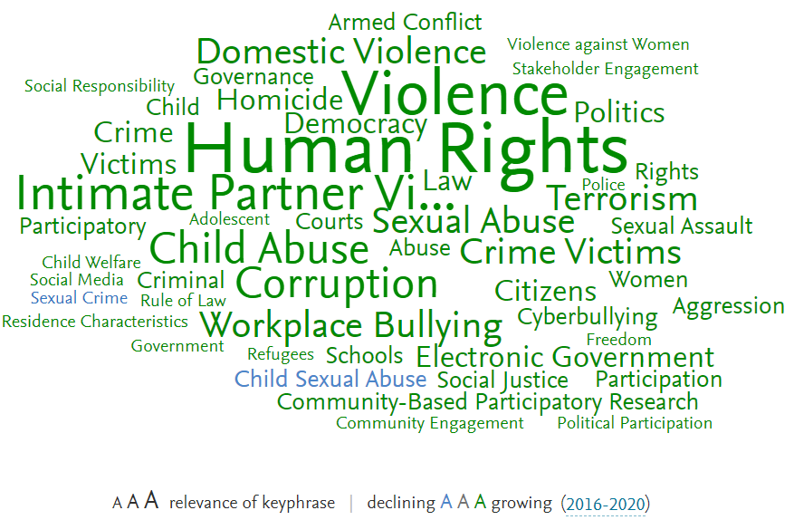

Explore this wordcloud plus the most active contributors on the [SciVal SDG site](https://scival.com/sdg)

## Query

Below is the full search query used for this SDG. We’ve broken it down by each query component. Use the + and – to concatenate the different bracket levels.

(

(

TITLE-ABS

(

"cronyism"

)

OR AUTHKEY

(

"cronyism"

)

OR TITLE-ABS

(

"freedom of thought"

)

OR AUTHKEY

(

"freedom of thought"

)

OR

(

TITLE-ABS

(

"aggressive relationship"

)

OR TITLE-ABS

(

"aggressive relationships"

)

)

OR

(

AUTHKEY

(

"aggressive relationship"

)

OR AUTHKEY

(

"aggressive relationships"

)

)

OR

(

TITLE-ABS

(

"abused adolescent"

)

OR TITLE-ABS

(

"abused adolescents"

)

)

OR

(

AUTHKEY

(

"abused adolescent"

)

OR AUTHKEY

(

"abused adolescents"

)

)

OR

(

TITLE-ABS

(

"batterer"

)

OR TITLE-ABS

(

"batterers"

)

)

OR

(

AUTHKEY

(

"batterer"

)

OR AUTHKEY

(

"batterers"

)

)

OR TITLE-ABS

(

"corruption dynamics"

)

OR AUTHKEY

(

"corruption dynamics"

)

OR TITLE-ABS

(

"extortion"

)

OR AUTHKEY

(

"extortion"

)

OR TITLE-ABS

(

"female violence"

)

OR AUTHKEY

(

"female violence"

)

OR

(

TITLE-ABS

(

"antidiscrimination policy"

)

OR TITLE-ABS

(

"antidiscrimination policies"

)

)

OR

(

AUTHKEY

(

"antidiscrimination policy"

)

OR AUTHKEY

(

"antidiscrimination policies"

)

)

OR TITLE-ABS

(

"electronic governance"

)

OR AUTHKEY

(

"electronic governance"

)

OR TITLE-ABS

(

"court interpreting"

)

OR AUTHKEY

(

"court interpreting"

)

OR TITLE-ABS

(

"gendered violence"

)

OR AUTHKEY

(

"gendered violence"

)

OR TITLE-ABS

(

"confidence in government"

)

OR AUTHKEY

(

"confidence in government"

)

OR

(

TITLE-ABS

(

"abused child"

)

OR TITLE-ABS

(

"abused children"

)

)

OR

(

AUTHKEY

(

"abused child"

)

OR AUTHKEY

(

"abused children"

)

)

OR

(

TITLE-ABS

(

"favoritism"

)

AND TITLE-ABS

(

"corruption"

)

)

OR

(

AUTHKEY

(

"favoritism"

)

AND AUTHKEY

(

"corruption"

)

)

OR TITLE-ABS

(

"corruption index"

)

OR AUTHKEY

(

"corruption index"

)

OR TITLE-ABS

(

"elder neglect"

)

OR AUTHKEY

(

"elder neglect"

)

OR

(

TITLE-ABS

(

"exploited child"

)

OR TITLE-ABS

(

"exploited children"

)

)

OR

(

AUTHKEY

(

"exploited child"

)

OR AUTHKEY

(

"exploited children"

)

)

OR TITLE-ABS

(

"child abuse"

)

OR AUTHKEY

(

"child abuse"

)

OR TITLE-ABS

(

"electronic democracy"

)

OR AUTHKEY

(

"electronic democracy"

)

OR TITLE-ABS

(

"criminal corruption"

)

OR AUTHKEY

(

"criminal corruption"

)

OR TITLE-ABS

(

"children abuse"

)

OR AUTHKEY

(

"children abuse"

)

OR TITLE-ABS

(

"economic freedom"

)

OR AUTHKEY

(

"economic freedom"

)

OR

(

TITLE-ABS

(

"feminist policy"

)

OR TITLE-ABS

(

"feminist policies"

)

)

OR

(

AUTHKEY

(

"feminist policy"

)

OR AUTHKEY

(

"feminist policies"

)

)

OR

(

TITLE-ABS

(

"firearm death"

)

OR TITLE-ABS

(

"firearm deaths"

)

)

OR

(

AUTHKEY

(

"firearm death"

)

OR AUTHKEY

(

"firearm deaths"

)

)

OR TITLE-ABS

(

"convention against corruption"

)

OR AUTHKEY

(

"convention against corruption"

)

OR

(

TITLE-ABS

(

"direct democracy"

)

OR TITLE-ABS

(

"direct democracies"

)

)

OR

(

AUTHKEY

(

"direct democracy"

)

OR AUTHKEY

(

"direct democracies"

)

)

OR TITLE-ABS

(

"bullying prevention"

)

OR AUTHKEY

(

"bullying prevention"

)

OR TITLE-ABS

(

"democratic accountability"

)

OR AUTHKEY

(

"democratic accountability"

)

OR TITLE-ABS

(

"bureaucratic corruption"

)

OR AUTHKEY

(

"bureaucratic corruption"

)

OR TITLE-ABS

(

"acquaintance rape"

)

OR AUTHKEY

(

"acquaintance rape"

)

OR

(

TITLE-ABS

(

"electoral manipulation"

)

OR TITLE-ABS

(

"electoral manipulations"

)

)

OR

(

AUTHKEY

(

"electoral manipulation"

)

OR AUTHKEY

(

"electoral manipulations"

)

)

OR

(

(

TITLE-ABS("antiterrorist") OR TITLE-ABS("anti-terrorist")

)

OR

(

TITLE-ABS("antiterrorist") OR TITLE-ABS("antiterrorist")

)

)

OR

(

(

AUTHKEY("antiterrorist") OR AUTHKEY("anti-terrorist")

)

OR

(

AUTHKEY("antiterrorist") OR AUTHKEY("antiterrorist")

)

)

OR TITLE-ABS

(

"community participation"

)

OR AUTHKEY

(

"community participation"

)

OR

(

TITLE-ABS

(

"assaulted woman"

)

OR TITLE-ABS

(

"assaulted women"

)

)

OR

(

AUTHKEY

(

"assaulted woman"

)

OR AUTHKEY

(

"assaulted women"

)

)

OR

(

TITLE-ABS

(

"fundamental freedom"

)

OR TITLE-ABS

(

"fundamental freedoms"

)

)

OR

(

AUTHKEY

(

"fundamental freedom"

)

OR AUTHKEY

(

"fundamental freedoms"

)

)

OR

(

TITLE-ABS

(

"form of corruption"

)

OR TITLE-ABS

(

"forms of corruption"

)

)

OR

(

AUTHKEY

(

"form of corruption"

)

OR AUTHKEY

(

"forms of corruption"

)

)

OR TITLE-ABS

(

"child aggression"

)

OR AUTHKEY

(

"child aggression"

)

OR TITLE-ABS

(

"fight against terrorism"

)

OR AUTHKEY

(

"fight against terrorism"

)

OR

(

TITLE-ABS

(

"criminal group"

)

OR TITLE-ABS

(

"criminal groups"

)

)

OR

(

AUTHKEY

(

"criminal group"

)

OR AUTHKEY

(

"criminal groups"

)

)

OR

(

(

TITLE-ABS("edemocracy") OR TITLE-ABS("e-democracy")

)

OR

(

TITLE-ABS("edemocracy") OR TITLE-ABS("edemocracy")

)

)

OR

(

(

AUTHKEY("edemocracy") OR AUTHKEY("e-democracy")

)

OR

(

AUTHKEY("edemocracy") OR AUTHKEY("edemocracy")

)

)

OR TITLE-ABS

(

"child exploitation"

)

OR AUTHKEY

(

"child exploitation"

)

OR

(

(

TITLE-ABS("antiterrorism") OR TITLE-ABS("anti-terrorism")

)

OR

(

TITLE-ABS("antiterrorism") OR TITLE-ABS("antiterrorism")

)

)

OR

(

(

AUTHKEY("antiterrorism") OR AUTHKEY("anti-terrorism")

)

OR

(

AUTHKEY("antiterrorism") OR AUTHKEY("antiterrorism")

)

)

OR TITLE-ABS

(

"corruption perception index"

)

OR AUTHKEY

(

"corruption perception index"

)

OR TITLE-ABS

(

"childhood rape"

)

OR AUTHKEY

(

"childhood rape"

)

OR

(

TITLE-ABS

(

"criminal gang"

)

OR TITLE-ABS

(

"criminal gangs"

)

)

OR

(

AUTHKEY

(

"criminal gang"

)

OR AUTHKEY

(

"criminal gangs"

)

)

OR TITLE-ABS

(

"access to information act"

)

OR AUTHKEY

(

"access to information act"

)

OR

(

TITLE-ABS

(

"abusive parent"

)

OR TITLE-ABS

(

"abusive parents"

)

)

OR

(

AUTHKEY

(

"abusive parent"

)

OR AUTHKEY

(

"abusive parents"

)

)

OR TITLE-ABS

(

"employee representation"

)

OR AUTHKEY

(

"employee representation"

)

OR TITLE-ABS

(

"digital government"

)

OR AUTHKEY

(

"digital government"

)

OR

(

TITLE-ABS

(

"criminal network"

)

OR TITLE-ABS

(

"criminal networks"

)

)

OR

(

AUTHKEY

(

"criminal network"

)

OR AUTHKEY

(

"criminal networks"

)

)

OR TITLE-ABS

(

"dating aggression"

)

OR AUTHKEY

(

"dating aggression"

)

OR TITLE-ABS

(

"equality of arms"

)

OR AUTHKEY

(

"equality of arms"

)

OR TITLE-ABS

(

"female rape"

)

OR AUTHKEY

(

"female rape"

)

OR

(

TITLE-ABS

(

"child worker"

)

OR TITLE-ABS

(

"child workers"

)

)

OR

(

AUTHKEY

(

"child worker"

)

OR AUTHKEY

(

"child workers"

)

)

OR TITLE-ABS

(

"civic engagement"

)

OR AUTHKEY

(

"civic engagement"

)

OR TITLE-ABS

(

"corruptibility"

)

OR AUTHKEY

(

"corruptibility"

)

OR TITLE-ABS

(

"child welfare"

)

OR AUTHKEY

(

"child welfare"

)

OR TITLE-ABS

(

"checks and balances"

)

OR AUTHKEY

(

"checks and balances"

)

OR TITLE-ABS

(

"elder maltreatment"

)

OR AUTHKEY

(

"elder maltreatment"

)

OR TITLE-ABS

(

"corruption reduction"

)

OR AUTHKEY

(

"corruption reduction"

)

OR

(

(

TITLE-ABS("cyberbullying") OR TITLE-ABS("cyber-bullying")

)

OR

(

TITLE-ABS("cyberbullying") OR TITLE-ABS("cyberbullying")

)

)

OR

(

(

AUTHKEY("cyberbullying") OR AUTHKEY("cyber-bullying")

)

OR

(

AUTHKEY("cyberbullying") OR AUTHKEY("cyberbullying")

)

)

OR TITLE-ABS

(

"aggression perpetration"

)

OR AUTHKEY

(

"aggression perpetration"

)

OR

(

TITLE-ABS

(

"antidiscrimination legislation"

)

OR TITLE-ABS

(

"antidiscrimination legislations"

)

)

OR

(

AUTHKEY

(

"antidiscrimination legislation"

)

OR AUTHKEY

(

"antidiscrimination legislations"

)

)

OR TITLE-ABS

(

"child protection"

)

OR AUTHKEY

(

"child protection"

)

OR TITLE-ABS

(

"bank corruption"

)

OR AUTHKEY

(

"bank corruption"

)

OR

(

TITLE-ABS

(

"discrimination law"

)

OR TITLE-ABS

(

"discrimination laws"

)

)

OR

(

AUTHKEY

(

"discrimination law"

)

OR AUTHKEY

(

"discrimination laws"

)

)

OR TITLE-ABS

(

"freedom of media"

)

OR AUTHKEY

(

"freedom of media"

)

OR TITLE-ABS

(

"freedom of expression"

)

OR AUTHKEY

(

"freedom of expression"

)

OR TITLE-ABS

(

"arms smuggling"

)

OR AUTHKEY

(

"arms smuggling"

)

OR TITLE-ABS

(

"abuse of women"

)

OR AUTHKEY

(

"abuse of women"

)

OR TITLE-ABS

(

"freedom of information"

)

OR AUTHKEY

(

"freedom of information"

)

OR

(

TITLE-ABS

(

"firearm control"

)

OR TITLE-ABS

(

"firearm control"

)

)

OR

(

AUTHKEY

(

"firearm control"

)

OR AUTHKEY

(

"firearm control"

)

)

OR

(

TITLE-ABS

(

"firearm law"

)

OR TITLE-ABS

(

"firearm laws"

)

)

OR

(

AUTHKEY

(

"firearm law"

)

OR AUTHKEY

(

"firearm laws"

)

)

OR

(

TITLE-ABS

(

"equality legislation"

)

OR TITLE-ABS

(

"equality legislations"

)

)

OR

(

AUTHKEY

(

"equality legislation"

)

OR AUTHKEY

(

"equality legislations"

)

)

OR

(

TITLE-ABS

(

"abused elder"

)

OR TITLE-ABS

(

"abused elders"

)

)

OR

(

AUTHKEY

(

"abused elder"

)

OR AUTHKEY

(

"abused elders"

)

)

OR

(

(

TITLE-ABS("first-degree murder") OR TITLE-ABS("first-degree murders")

)

OR

(

TITLE-ABS("firstdegree murder") OR TITLE-ABS("firstdegree murders")

)

)

OR

(

(

AUTHKEY("first-degree murder") OR AUTHKEY("first-degree murders")

)

OR

(

AUTHKEY("firstdegree murder") OR AUTHKEY("firstdegree murders")

)

)

OR TITLE-ABS

(

"forced sex"

)

OR AUTHKEY

(

"forced sex"

)

OR TITLE-ABS

(

"abuse against women"

)

OR AUTHKEY

(

"abuse against women"

)

OR

(

TITLE-ABS

(

"corrupt practice"

)

OR TITLE-ABS

(

"corrupt practices"

)

)

OR

(

AUTHKEY

(

"corrupt practice"

)

OR AUTHKEY

(

"corrupt practices"

)

)

OR

(

TITLE-ABS

(

"firearm legislation"

)

OR TITLE-ABS

(

"firearm legislations"

)

)

OR

(

AUTHKEY

(

"firearm legislation"

)

OR AUTHKEY

(

"firearm legislations"

)

)

OR

(

TITLE-ABS

(

"civil liberty"

)

OR TITLE-ABS

(

"civil liberties"

)

)

OR

(

AUTHKEY

(

"civil liberty"

)

OR AUTHKEY

(

"civil liberties"

)

)

OR

(

(

TITLE-ABS("antimafia") OR TITLE-ABS("anti-mafia")

)

OR

(

TITLE-ABS("antimafia") OR TITLE-ABS("antimafia")

)

)

OR

(

(

AUTHKEY("antimafia") OR AUTHKEY("anti-mafia")

)

OR

(

AUTHKEY("antimafia") OR AUTHKEY("antimafia")

)

)

OR

(

TITLE-ABS

(

"bullied student"

)

OR TITLE-ABS

(

"bullied students"

)

)

OR

(

AUTHKEY

(

"bullied student"

)

OR AUTHKEY

(

"bullied students"

)

)

OR

(

TITLE-ABS

(

"firearm mortality"

)

OR TITLE-ABS

(

"firearm mortalities"

)

)

OR

(

AUTHKEY

(

"firearm mortality"

)

OR AUTHKEY

(

"firearm mortalities"

)

)

OR TITLE-ABS

(

"combating terror"

)

OR AUTHKEY

(

"combating terror"

)

OR TITLE-ABS

(

"access to information legislation"

)

OR AUTHKEY

(

"access to information legislation"

)

OR

(

TITLE-ABS

(

"antidiscrimination law"

)

OR TITLE-ABS

(

"antidiscrimination laws"

)

)

OR

(

AUTHKEY

(

"antidiscrimination law"

)

OR AUTHKEY

(

"antidiscrimination laws"

)

)

OR TITLE-ABS

(

"electoral fraud"

)

OR AUTHKEY

(

"electoral fraud"

)

OR

(

TITLE-ABS

(

"discrimination act"

)

OR TITLE-ABS

(

"discrimination acts"

)

)

OR

(

AUTHKEY

(

"discrimination act"

)

OR AUTHKEY

(

"discrimination acts"

)

)

OR

(

TITLE-ABS

(

"corrupt politician"

)

OR TITLE-ABS

(

"corrupt politicians"

)

)

OR

(

AUTHKEY

(

"corrupt politician"

)

OR AUTHKEY

(

"corrupt politicians"

)

)

OR TITLE-ABS

(

"blackmailing"

)

OR AUTHKEY

(

"blackmailing"

)

OR

(

TITLE-ABS

(

"filicide"

)

OR TITLE-ABS

(

"filicides"

)

)

OR

(

AUTHKEY

(

"filicide"

)

OR AUTHKEY

(

"filicides"

)

)

OR TITLE-ABS

(

"dating violence"

)

OR AUTHKEY

(

"dating violence"

)

OR

(

TITLE-ABS

(

"court interpreter"

)

OR TITLE-ABS

(

"court interpreters"

)

)

OR

(

AUTHKEY

(

"court interpreter"

)

OR AUTHKEY

(

"court interpreters"

)

)

OR

(

(

TITLE-ABS("antitrafficking") OR TITLE-ABS("anti-trafficking")

)

OR

(

TITLE-ABS("antitrafficking") OR TITLE-ABS("antitrafficking")

)

)

OR

(

(

AUTHKEY("antitrafficking") OR AUTHKEY("anti-trafficking")

)

OR

(

AUTHKEY("antitrafficking") OR AUTHKEY("antitrafficking")

)

)

OR

(

TITLE-ABS

(

"discriminatory policy"

)

OR TITLE-ABS

(

"discriminatory policies"

)

)

OR

(

AUTHKEY

(

"discriminatory policy"

)

OR AUTHKEY

(

"discriminatory policies"

)

)

OR

(

TITLE-ABS

(

"discriminatory act"

)

OR TITLE-ABS

(

"discriminatory acts"

)

)

OR

(

AUTHKEY

(

"discriminatory act"

)

OR AUTHKEY

(

"discriminatory acts"

)

)

OR TITLE-ABS

(

"access to government"

)

OR AUTHKEY

(

"access to government"

)

OR TITLE-ABS

(

"abuse in childhood"

)

OR AUTHKEY

(

"abuse in childhood"

)

OR TITLE-ABS

(

"adolescent aggression"

)

OR AUTHKEY

(

"adolescent aggression"

)

OR TITLE-ABS

(

"domestic violence"

)

OR AUTHKEY

(

"domestic violence"

)

OR TITLE-ABS

(

"community involvement"

)

OR AUTHKEY

(

"community involvement"

)

OR

(

TITLE-ABS

(

"discriminatory law"

)

OR TITLE-ABS

(

"discriminatory laws"

)

)

OR

(

AUTHKEY

(

"discriminatory law"

)

OR AUTHKEY

(

"discriminatory laws"

)

)

OR

(

TITLE-ABS

(

"firearm fatality"

)

OR TITLE-ABS

(

"firearm fatalities"

)

)

OR

(

AUTHKEY

(

"firearm fatality"

)

OR AUTHKEY

(

"firearm fatalities"

)

)

OR

(

TITLE-ABS

(

"crime network"

)

OR TITLE-ABS

(

"crime networks"

)

)

OR

(

AUTHKEY

(

"crime network"

)

OR AUTHKEY

(

"crime networks"

)

)

OR

(

TITLE-ABS

(

"feminicide"

)

OR TITLE-ABS

(

"feminicides"

)

)

OR

(

AUTHKEY

(

"feminicide"

)

OR AUTHKEY

(

"feminicides"

)

)

OR

(

TITLE-ABS

(

"abuse in pregnancy"

)

AND NOT

(

(TITLE-ABS("alcohol abuse") OR TITLE-ABS("drug abuse") OR TITLE-ABS("substance abuse") OR TITLE-ABS("cocaine abuse") OR TITLE-ABS("ethanol abuse"))

)

)

OR

(

AUTHKEY

(

"abuse in pregnancy"

)

AND NOT

(

(AUTHKEY("alcohol abuse") OR AUTHKEY("drug abuse") OR AUTHKEY("substance abuse") OR AUTHKEY("cocaine abuse") OR AUTHKEY("ethanol abuse"))

)

)

OR

(

TITLE-ABS

(

"access to information law"

)

OR TITLE-ABS

(

"access to information laws"

)

)

OR

(

AUTHKEY

(

"access to information law"

)

OR AUTHKEY

(

"access to information laws"

)

)

OR

(

(

TITLE-ABS("anticorruption") OR TITLE-ABS("anti-corruption")

)

OR

(

TITLE-ABS("anticorruption") OR TITLE-ABS("anticorruption")

)

)

OR

(

(

AUTHKEY("anticorruption") OR AUTHKEY("anti-corruption")

)

OR

(

AUTHKEY("anticorruption") OR AUTHKEY("anticorruption")

)

)

OR

(

(

TITLE-ABS("egovernance") OR TITLE-ABS("e-governance")

)

OR

(

TITLE-ABS("egovernance") OR TITLE-ABS("egovernance")

)

)

OR

(

(

AUTHKEY("egovernance") OR AUTHKEY("e-governance")

)

OR

(

AUTHKEY("egovernance") OR AUTHKEY("egovernance")

)

)

OR TITLE-ABS

(

"dating abuse"

)

OR AUTHKEY

(

"dating abuse"

)

OR

(

TITLE-ABS

(

"active citizen"

)

OR TITLE-ABS

(

"active citizens"

)

)

OR

(

AUTHKEY

(

"active citizen"

)

OR AUTHKEY

(

"active citizens"

)

)

OR TITLE-ABS

(

"corruption deterrence"

)

OR AUTHKEY

(

"corruption deterrence"

)

OR TITLE-ABS

(

"combating terrorism"

)

OR AUTHKEY

(

"combating terrorism"

)

OR

(

TITLE-ABS

(

"gender-based violence"

)

OR TITLE-ABS

(

"genderbased violence"

)

)

OR

(

AUTHKEY

(

"gender-based violence"

)

OR AUTHKEY

(

"genderbased violence"

)

)

OR

(

TITLE-ABS

(

"feminist regulation"

)

OR TITLE-ABS

(

"feminist regulations"

)

)

OR

(

AUTHKEY

(

"feminist regulation"

)

OR AUTHKEY

(

"feminist regulations"

)

)

OR TITLE-ABS

(

"abusive parenting"

)

OR AUTHKEY

(

"abusive parenting"

)

OR TITLE-ABS

(

"patronage politics"

)

OR AUTHKEY

(

"patronage politics"

)

OR TITLE-ABS

(

"corruption prevention"

)

OR AUTHKEY

(

"corruption prevention"

)

OR

(

TITLE-ABS

(

"corrupt act"

)

OR TITLE-ABS

(

"corrupt acts"

)

)

OR

(

AUTHKEY

(

"corrupt act"

)

OR AUTHKEY

(

"corrupt acts"

)

)

OR TITLE-ABS

(

"trust in the government"

)

OR AUTHKEY

(

"trust in the government"

)

OR

(

TITLE-ABS

(

"inequality act"

)

OR TITLE-ABS

(

"inequality acts"

)

)

OR

(

AUTHKEY

(

"inequality act"

)

OR AUTHKEY

(

"inequality acts"

)

)

OR

(

TITLE-ABS

(

"violent offender"

)

OR TITLE-ABS

(

"violent offenders"

)

)

OR

(

AUTHKEY

(

"violent offender"

)

OR AUTHKEY

(

"violent offenders"

)

)

OR TITLE-ABS

(

"legal empowerment"

)

OR AUTHKEY

(

"legal empowerment"

)

OR

(

TITLE-ABS

(

"firearm regulation"

)

OR TITLE-ABS

(

"firearm regulations"

)

)

OR

(

AUTHKEY

(

"firearm regulation"

)

OR AUTHKEY

(

"firearm regulations"

)

)

OR

(

TITLE-ABS

(

"discrimination legislation"

)

OR TITLE-ABS

(

"discrimination legislations"

)

)

OR

(

AUTHKEY

(

"discrimination legislation"

)

OR AUTHKEY

(

"discrimination legislations"

)

)

OR TITLE-ABS

(

"judicial impartiality"

)

OR AUTHKEY

(

"judicial impartiality"

)

OR

(

(

TITLE-ABS("round-trip transaction") OR TITLE-ABS("round-trip transactions")

)

OR

(

TITLE-ABS("roundtrip transaction") OR TITLE-ABS("roundtrip transactions")

)

)

OR

(

(

AUTHKEY("round-trip transaction") OR AUTHKEY("round-trip transactions")

)

OR

(

AUTHKEY("roundtrip transaction") OR AUTHKEY("roundtrip transactions")

)

)

OR

(

(

TITLE-ABS("counterterrorism") OR TITLE-ABS("counter-terrorism")

)

OR

(

TITLE-ABS("counterterrorism") OR TITLE-ABS("counterterrorism")

)

)

OR

(

(

AUTHKEY("counterterrorism") OR AUTHKEY("counter-terrorism")

)

OR

(

AUTHKEY("counterterrorism") OR AUTHKEY("counterterrorism")

)

)

OR TITLE-ABS

(

"violent women"

)

OR AUTHKEY

(

"violent women"

)

OR TITLE-ABS

(

"legal interpreting"

)

OR AUTHKEY

(

"legal interpreting"

)

OR TITLE-ABS

(

"worker participation"

)

OR AUTHKEY

(

"worker participation"

)

OR

(

TITLE-ABS

(

"sexual murder"

)

OR TITLE-ABS

(

"sexual murders"

)

)

OR

(

AUTHKEY

(

"sexual murder"

)

OR AUTHKEY

(

"sexual murders"

)

)

OR TITLE-ABS

(

"paternal abuse"

)

OR AUTHKEY

(

"paternal abuse"

)

OR

(

TITLE-ABS

(

"politicide"

)

OR TITLE-ABS

(

"politicides"

)

)

OR

(

AUTHKEY

(

"politicide"

)

OR AUTHKEY

(

"politicides"

)

)

OR TITLE-ABS

(

"violence against men"

)

OR AUTHKEY

(

"violence against men"

)

OR

(

(

TITLE-ABS("participatory decision-making") OR TITLE-ABS("participatory decisionmaking")

)

OR

(

TITLE-ABS("participatory decisionmaking") OR TITLE-ABS("participatory decisionmaking")

)

)

OR

(

(

AUTHKEY("participatory decision-making") OR AUTHKEY("participatory decisionmaking")

)

OR

(

AUTHKEY("participatory decisionmaking") OR AUTHKEY("participatory decisionmaking")

)

)

OR

(

TITLE-ABS

(

"antidiscriminatory legislation"

)

OR TITLE-ABS

(

"antidiscriminatory legislations"

)

)

OR

(

AUTHKEY

(

"antidiscriminatory legislation"

)

OR AUTHKEY

(

"antidiscriminatory legislations"

)

)

OR

(

TITLE-ABS

(

"engaged citizen"

)

OR TITLE-ABS

(

"engaged citizens"

)

)

OR

(

AUTHKEY

(

"engaged citizen"

)

OR AUTHKEY

(

"engaged citizens"

)

)

OR

(

TITLE-ABS

(

"corrupt action"

)

OR TITLE-ABS

(

"corrupt actions"

)

)

OR

(

AUTHKEY

(

"corrupt action"

)

OR AUTHKEY

(

"corrupt actions"

)

)

OR

(

TITLE-ABS

(

"forced labour"

)

OR TITLE-ABS

(

"forced labor"

)

)

OR

(

AUTHKEY

(

"forced labour"

)

OR AUTHKEY

(

"forced labor"

)

)

OR

(

TITLE-ABS

(

"bullied child"

)

OR TITLE-ABS

(

"bullied children"

)

)

OR

(

AUTHKEY

(

"bullied child"

)

OR AUTHKEY

(

"bullied children"

)

)

OR TITLE-ABS

(

"physical bullying"

)

OR AUTHKEY

(

"physical bullying"

)

OR TITLE-ABS

(

"child prostitution"

)

OR AUTHKEY

(

"child prostitution"

)

OR

(

TITLE-ABS

(

"abused woman"

)

OR TITLE-ABS

(

"abused women"

)

)

OR

(

AUTHKEY

(

"abused woman"

)

OR AUTHKEY

(

"abused women"

)

)

OR

(

TITLE-ABS

(

"organized crime"

)

OR TITLE-ABS

(

"organised crime"

)

)

OR

(

AUTHKEY

(

"organized crime"

)

OR AUTHKEY

(

"organised crime"

)

)

OR TITLE-ABS

(

"gang rape"

)

OR AUTHKEY

(

"gang rape"

)

OR TITLE-ABS

(

"stranger rape"

)

OR AUTHKEY

(

"stranger rape"

)

OR

(

TITLE-ABS

(

"act against discrimination"

)

OR TITLE-ABS

(

"acts against discrimination"

)

)

OR

(

AUTHKEY

(

"act against discrimination"

)

OR AUTHKEY

(

"acts against discrimination"

)

)

OR

(

TITLE-ABS

(

"perpetrator of violence"

)

OR TITLE-ABS

(

"perpetrators of violence"

)

)

OR

(

AUTHKEY

(

"perpetrator of violence"

)

OR AUTHKEY

(

"perpetrators of violence"

)

)

OR TITLE-ABS

(

"fighting corruption"

)

OR AUTHKEY

(

"fighting corruption"

)

OR TITLE-ABS

(

"combat terrorism"

)

OR AUTHKEY

(

"combat terrorism"

)

OR

(

TITLE-ABS

(

"terrorist group"

)

OR TITLE-ABS

(

"terrorist groups"

)

)

OR

(

AUTHKEY

(

"terrorist group"

)

OR AUTHKEY

(

"terrorist groups"

)

)

OR TITLE-ABS

(

"control of corruption"

)

OR AUTHKEY

(

"control of corruption"

)

OR TITLE-ABS

(

"child neglect"

)

OR AUTHKEY

(

"child neglect"

)

OR

(

TITLE-ABS

(

"battered woman"

)

OR TITLE-ABS

(

"battered women"

)

)

OR

(

AUTHKEY

(

"battered woman"

)

OR AUTHKEY

(

"battered women"

)

)

OR TITLE-ABS

(

"war against terrorism"

)

OR AUTHKEY

(

"war against terrorism"

)

OR

(

TITLE-ABS

(

"individual freedom"

)

OR TITLE-ABS

(

"individual freedoms"

)

)

OR

(

AUTHKEY

(

"individual freedom"

)

OR AUTHKEY

(

"individual freedoms"

)

)

OR

(

TITLE-ABS

(

"nondiscriminatory policy"

)

OR TITLE-ABS

(

"nondiscriminatory policies"

)

)

OR

(

AUTHKEY

(

"nondiscriminatory policy"

)

OR AUTHKEY

(

"nondiscriminatory policies"

)

)

OR TITLE-ABS

(

"political corruption"

)

OR AUTHKEY

(

"political corruption"

)

OR TITLE-ABS

(

"fraudulent transfer pricing"

)

OR AUTHKEY

(

"fraudulent transfer pricing"

)

OR TITLE-ABS

(

"child work"

)

OR AUTHKEY

(

"child work"

)

OR

(

TITLE-ABS

(

"feminist law"

)

OR TITLE-ABS

(

"feminist laws"

)

)

OR

(

AUTHKEY

(

"feminist law"

)

OR AUTHKEY

(

"feminist laws"

)

)

OR

(

(

TITLE-ABS("firearm-related death") OR TITLE-ABS("firearm-related deaths")

)

OR

(

TITLE-ABS("firearmrelated death") OR TITLE-ABS("firearmrelated deaths")

)

)

OR

(

(

AUTHKEY("firearm-related death") OR AUTHKEY("firearm-related deaths")

)

OR

(

AUTHKEY("firearmrelated death") OR AUTHKEY("firearmrelated deaths")

)

)

OR TITLE-ABS

(

"corruption in organizations"

)

OR AUTHKEY

(

"corruption in organizations"

)

OR TITLE-ABS

(

"couple violence"

)

OR AUTHKEY

(

"couple violence"

)

OR TITLE-ABS

(

"sexually coercive"

)

OR AUTHKEY

(

"sexually coercive"

)

OR

(

TITLE-ABS

(

"corruption level"

)

OR TITLE-ABS

(

"corruption levels"

)

)

OR

(

AUTHKEY

(

"corruption level"

)

OR AUTHKEY

(

"corruption levels"

)

)

OR TITLE-ABS

(

"clientelism"

)

OR AUTHKEY

(

"clientelism"

)

OR TITLE-ABS

(

"child rape"

)

OR AUTHKEY

(

"child rape"

)

OR

(

TITLE-ABS

(

"transparent government"

)

OR TITLE-ABS

(

"transparent governments"

)

)

OR

(

AUTHKEY

(

"transparent government"

)

OR AUTHKEY

(

"transparent governments"

)

)

OR TITLE-ABS

(

"workplace harassment"

)

OR AUTHKEY

(

"workplace harassment"

)

OR TITLE-ABS

(

"partner violence"

)

OR AUTHKEY

(

"partner violence"

)

OR TITLE-ABS

(

"politics of patronage"

)

OR AUTHKEY

(

"politics of patronage"

)

OR TITLE-ABS

(

"electoral accountability"

)

OR AUTHKEY

(

"electoral accountability"

)

OR TITLE-ABS

(

"blackmail"

)

OR AUTHKEY

(

"blackmail"

)

OR

(

(

TITLE-ABS("conflict-related death") OR TITLE-ABS("conflict-related deaths")

)

OR

(

TITLE-ABS("conflictrelated death") OR TITLE-ABS("conflictrelated deaths")

)

)

OR

(

(

AUTHKEY("conflict-related death") OR AUTHKEY("conflict-related deaths")

)

OR

(

AUTHKEY("conflictrelated death") OR AUTHKEY("conflictrelated deaths")

)

)

OR TITLE-ABS

(

"preventing violence"

)

OR AUTHKEY

(

"preventing violence"

)

OR

(

TITLE-ABS

(

"law against discrimination"

)

OR TITLE-ABS

(

"laws against discrimination"

)

)

OR

(

AUTHKEY

(

"law against discrimination"

)

OR AUTHKEY

(

"laws against discrimination"

)

)

OR TITLE-ABS

(

"access to government information"

)

OR AUTHKEY

(

"access to government information"

)

OR TITLE-ABS

(

"social aggression"

)

OR AUTHKEY

(

"social aggression"

)

OR TITLE-ABS

(

"industrial democracy"

)

OR AUTHKEY

(

"industrial democracy"

)

OR TITLE-ABS

(

"murdered"

)

OR AUTHKEY

(

"murdered"

)

OR

(

TITLE-ABS

(

"bullying victim"

)

OR TITLE-ABS

(

"bullying victims"

)

)

OR

(

AUTHKEY

(

"bullying victim"

)

OR AUTHKEY

(

"bullying victims"

)

)

OR

(

TITLE-ABS

(

"open institution"

)

OR TITLE-ABS

(

"open institutions"

)

)

OR

(

AUTHKEY

(

"open institution"

)

OR AUTHKEY

(

"open institutions"

)

)

OR TITLE-ABS

(

"political engagement"

)

OR AUTHKEY

(

"political engagement"

)

OR TITLE-ABS

(

"freedom of opinion"

)

OR AUTHKEY

(

"freedom of opinion"

)

OR TITLE-ABS

(

"youth pornography"

)

OR AUTHKEY

(

"youth pornography"

)

OR TITLE-ABS

(

"juvenile violence"

)

OR AUTHKEY

(

"juvenile violence"

)

OR

(

(

TITLE-ABS("involvement in decision-making") OR TITLE-ABS("involvement in decisionmaking")

)

OR

(

TITLE-ABS("involvement in decisionmaking") OR TITLE-ABS("involvement in decisionmaking")

)

)

OR

(

(

AUTHKEY("involvement in decision-making") OR AUTHKEY("involvement in decisionmaking")

)

OR

(

AUTHKEY("involvement in decisionmaking") OR AUTHKEY("involvement in decisionmaking")

)

)

OR TITLE-ABS

(

"sexual maltreatment"

)

OR AUTHKEY

(

"sexual maltreatment"

)

OR TITLE-ABS

(

"smuggling of weapons"

)

OR AUTHKEY

(

"smuggling of weapons"

)

OR

(

TITLE-ABS

(

"child murder"

)

OR TITLE-ABS

(

"child murders"

)

)

OR

(

AUTHKEY

(

"child murder"

)

OR AUTHKEY

(

"child murders"

)

)

OR TITLE-ABS

(

"elder mistreatment"

)

OR AUTHKEY

(

"elder mistreatment"

)

OR

(

TITLE-ABS

(

"violent offence"

)

OR TITLE-ABS

(

"violent offences"

)

)

OR

(

AUTHKEY

(

"violent offence"

)

OR AUTHKEY

(

"violent offences"

)

)

OR TITLE-ABS

(

"government transparency"

)

OR AUTHKEY

(

"government transparency"

)

OR

(

TITLE-ABS

(

"battered child"

)

OR TITLE-ABS

(

"battered children"

)

)

OR

(

AUTHKEY

(

"battered child"

)

OR AUTHKEY

(

"battered children"

)

)

OR TITLE-ABS

(

"maternal abuse"

)

OR AUTHKEY

(

"maternal abuse"

)

OR TITLE-ABS

(

"information transparency"

)

OR AUTHKEY

(

"information transparency"

)

OR TITLE-ABS

(

"adolescent abuse"

)

OR AUTHKEY

(

"adolescent abuse"

)

OR

(

TITLE-ABS

(

"child prostitute"

)

OR TITLE-ABS

(

"child prostitutes"

)

)

OR

(

AUTHKEY

(

"child prostitute"

)

OR AUTHKEY

(

"child prostitutes"

)

)

OR TITLE-ABS

(

"political imprisonment"

)

OR AUTHKEY

(

"political imprisonment"

)

OR TITLE-ABS

(

"freedom of religion"

)

OR AUTHKEY

(

"freedom of religion"

)

OR

(

TITLE-ABS

(

"abusive partner"

)

OR TITLE-ABS

(

"abusive partners"

)

)

OR

(

AUTHKEY

(

"abusive partner"

)

OR AUTHKEY

(

"abusive partners"

)

)

OR TITLE-ABS

(

"combatting corruption"

)

OR AUTHKEY

(

"combatting corruption"

)

OR TITLE-ABS

(

"judicial favoritism"

)

OR AUTHKEY

(

"judicial favoritism"

)

OR

(

TITLE-ABS

(

"terrorist organization"

)

OR TITLE-ABS

(

"terrorist organizations"

)

)

OR

(

AUTHKEY

(

"terrorist organization"

)

OR AUTHKEY

(

"terrorist organizations"

)

)

OR TITLE-ABS

(

"private corruption"

)

OR AUTHKEY

(

"private corruption"

)

OR TITLE-ABS

(

"right to information"

)

OR AUTHKEY

(

"right to information"

)

OR

(

TITLE-ABS

(

"right of the accused"

)

OR TITLE-ABS

(

"rights of the accused"

)

)

OR

(

AUTHKEY

(

"right of the accused"

)

OR AUTHKEY

(

"rights of the accused"

)

)

OR

(

TITLE-ABS

(

"abusive relationship"

)

OR TITLE-ABS

(

"abusive relationships"

)

)

OR

(

AUTHKEY

(

"abusive relationship"

)

OR AUTHKEY

(

"abusive relationships"

)

)

OR

(

(

TITLE-ABS("inclusive decision-making") OR TITLE-ABS("inclusive decisionmaking")

)

OR

(

TITLE-ABS("inclusive decisionmaking") OR TITLE-ABS("inclusive decisionmaking")

)

)

OR

(

(

AUTHKEY("inclusive decision-making") OR AUTHKEY("inclusive decisionmaking")

)

OR

(

AUTHKEY("inclusive decisionmaking") OR AUTHKEY("inclusive decisionmaking")

)

)

OR TITLE-ABS

(

"gay rights"

)

OR AUTHKEY

(

"gay rights"

)

OR

(

TITLE-ABS

(

"legal identity"

)

OR TITLE-ABS

(

"legal identities"

)

)

OR

(

AUTHKEY

(

"legal identity"

)

OR AUTHKEY

(

"legal identities"

)

)

OR

(

TITLE-ABS

(

"battered mother"

)

OR TITLE-ABS

(

"battered mothers"

)

)

OR

(

AUTHKEY

(

"battered mother"

)

OR AUTHKEY

(

"battered mothers"

)

)

OR

(

TITLE-ABS

(

"antidiscriminatory act"

)

OR TITLE-ABS

(

"antidiscriminatory acts"

)

)

OR

(

AUTHKEY

(

"antidiscriminatory act"

)

OR AUTHKEY

(

"antidiscriminatory acts"

)

)

OR

(

TITLE-ABS

(

"violent partner"

)

OR TITLE-ABS

(

"violent partners"

)

)

OR

(

AUTHKEY

(

"violent partner"

)

OR AUTHKEY

(

"violent partners"

)

)

OR TITLE-ABS

(

"gun safety"

)

OR AUTHKEY

(

"gun safety"

)

OR

(

TITLE-ABS

(

"abused mother"

)

OR TITLE-ABS

(

"abused mothers"

)

)

OR

(

AUTHKEY

(

"abused mother"

)

OR AUTHKEY

(

"abused mothers"

)

)

OR TITLE-ABS

(

"confidence in public institutions"

)

OR AUTHKEY

(

"confidence in public institutions"

)

OR TITLE-ABS

(

"combat corruption"

)

OR AUTHKEY

(

"combat corruption"

)

OR TITLE-ABS

(

"online bullying"

)

OR AUTHKEY

(

"online bullying"

)

OR

(

TITLE-ABS

(

"cause of corruption"

)

OR TITLE-ABS

(

"causes of corruption"

)

)

OR

(

AUTHKEY

(

"cause of corruption"

)

OR AUTHKEY

(

"causes of corruption"

)

)

OR TITLE-ABS

(

"psychological aggression"

)

OR AUTHKEY

(

"psychological aggression"

)

OR TITLE-ABS

(

"business corruption"

)

OR AUTHKEY

(

"business corruption"

)

OR TITLE-ABS

(

"combat violence"

)

OR AUTHKEY

(

"combat violence"

)

OR

(

TITLE-ABS

(

"participative approach"

)

OR TITLE-ABS

(

"participative approaches"

)

)

OR

(

AUTHKEY

(

"participative approach"

)

OR AUTHKEY

(

"participative approaches"

)

)

OR

(

TITLE-ABS

(

"bullying in school"

)

OR TITLE-ABS

(

"bullying in schools"

)

)

OR

(

AUTHKEY

(

"bullying in school"

)

OR AUTHKEY

(

"bullying in schools"

)

)

OR

(

TITLE-ABS

(

"crime of corruption"

)

OR TITLE-ABS

(

"crimes of corruption"

)

)

OR

(

AUTHKEY

(

"crime of corruption"

)

OR AUTHKEY

(

"crimes of corruption"

)

)

OR

(

(

TITLE-ABS("antibullying") OR TITLE-ABS("anti-bullying")

)

OR

(

TITLE-ABS("antibullying") OR TITLE-ABS("antibullying")

)

)

OR

(

(

AUTHKEY("antibullying") OR AUTHKEY("anti-bullying")

)

OR

(

AUTHKEY("antibullying") OR AUTHKEY("antibullying")

)

)

OR

(

TITLE-ABS

(

"equality law"

)

OR TITLE-ABS

(

"equality laws"

)

)

OR

(

AUTHKEY

(

"equality law"

)

OR AUTHKEY

(

"equality laws"

)

)

OR TITLE-ABS

(

"school aggression"

)

OR AUTHKEY

(

"school aggression"

)

OR

(

TITLE-ABS

(

"violent offense"

)

OR TITLE-ABS

(

"violent offenses"

)

)

OR

(

AUTHKEY

(

"violent offense"

)

OR AUTHKEY

(

"violent offenses"

)

)

OR TITLE-ABS

(

"administrative corruption"

)

OR AUTHKEY

(

"administrative corruption"

)

OR

(

(

TITLE-ABS("representative decision-making") OR TITLE-ABS("representative decisionmaking")

)

OR

(

TITLE-ABS("representative decisionmaking") OR TITLE-ABS("representative decisionmaking")

)

)

OR

(

(

AUTHKEY("representative decision-making") OR AUTHKEY("representative decisionmaking")

)

OR

(

AUTHKEY("representative decisionmaking") OR AUTHKEY("representative decisionmaking")

)

)

OR TITLE-ABS

(

"bullying at school"

)

OR AUTHKEY

(

"bullying at school"

)

OR

(

TITLE-ABS

(

"civil right"

)

OR TITLE-ABS

(

"civil rights"

)

)

OR

(

AUTHKEY

(

"civil right"

)

OR AUTHKEY

(

"civil rights"

)

)

OR TITLE-ABS

(

"islamic state of iraq and the levant"

)

OR AUTHKEY

(

"islamic state of iraq and the levant"

)

OR TITLE-ABS

(

"workplace aggression"

)

OR AUTHKEY

(

"workplace aggression"

)

OR

(

TITLE-ABS

(

"antidiscriminatory law"

)

OR TITLE-ABS

(

"antidiscriminatory laws"

)

)

OR

(

AUTHKEY

(

"antidiscriminatory law"

)

OR AUTHKEY

(

"antidiscriminatory laws"

)

)

OR

(

TITLE-ABS

(

"corruption crime"

)

OR TITLE-ABS

(

"corruption crimes"

)

)

OR

(

AUTHKEY

(

"corruption crime"

)

OR AUTHKEY

(

"corruption crimes"

)

)

OR

(

TITLE-ABS

(

"corruption counteraction"

)

OR TITLE-ABS

(

"corruption counteractions"

)

)

OR

(

AUTHKEY

(

"corruption counteraction"

)

OR AUTHKEY

(

"corruption counteractions"

)

)

OR TITLE-ABS

(

"emotional maltreatment"

)

OR AUTHKEY

(

"emotional maltreatment"

)

OR

(

TITLE-ABS

(

"fair hearing"

)

OR TITLE-ABS

(

"fair hearings"

)

)

OR

(

AUTHKEY

(

"fair hearing"

)

OR AUTHKEY

(

"fair hearings"

)

)

OR TITLE-ABS

(

"spousal assault"

)

OR AUTHKEY

(

"spousal assault"

)

OR TITLE-ABS

(

"racketeering"

)

OR AUTHKEY

(

"racketeering"

)

OR

(

(

TITLE-ABS("embezzlement") OR TITLE-ABS("embezzlements")

)

AND

(

TITLE-ABS("corruption") OR TITLE-ABS("corrupt")

)

)

OR

(

(

AUTHKEY("embezzlement") OR AUTHKEY("embezzlements")

)

AND

(

AUTHKEY("corruption") OR AUTHKEY("corrupt")

)

)

OR TITLE-ABS

(

"civic participation"

)

OR AUTHKEY

(

"civic participation"

)

OR TITLE-ABS

(

"war on terrorism"

)

OR AUTHKEY

(

"war on terrorism"

)

OR

(

(

TITLE-ABS("cyberaggression") OR TITLE-ABS("cyber-aggression")

)

OR

(

TITLE-ABS("cyberaggression") OR TITLE-ABS("cyberaggression")

)

)

OR

(

(

AUTHKEY("cyberaggression") OR AUTHKEY("cyber-aggression")

)

OR

(

AUTHKEY("cyberaggression") OR AUTHKEY("cyberaggression")

)

)

OR

(

TITLE-ABS

(

"corrupt official"

)

OR TITLE-ABS

(

"corrupt officials"

)

)

OR

(

AUTHKEY

(

"corrupt official"

)

OR AUTHKEY

(

"corrupt officials"

)

)

OR

(

TITLE-ABS

(

"accountable government"

)

OR TITLE-ABS

(

"accountable governments"

)

)

OR

(

AUTHKEY

(

"accountable government"

)

OR AUTHKEY

(

"accountable governments"

)

)

OR TITLE-ABS

(

"sexual violence"

)

OR AUTHKEY

(

"sexual violence"

)

OR TITLE-ABS

(

"marital rape"

)

OR AUTHKEY

(

"marital rape"

)

OR

(

(

TITLE-ABS("counterterror") OR TITLE-ABS("counter-terror")

)

OR

(

TITLE-ABS("counterterror") OR TITLE-ABS("counterterror")

)

)

OR

(

(

AUTHKEY("counterterror") OR AUTHKEY("counter-terror")

)

OR

(

AUTHKEY("counterterror") OR AUTHKEY("counterterror")

)

)

OR TITLE-ABS

(

"psychological harassment"

)

OR AUTHKEY

(

"psychological harassment"

)

OR TITLE-ABS

(

"rape prevention"

)

OR AUTHKEY

(

"rape prevention"

)

OR

(

(

TITLE-ABS("cyberharassment") OR TITLE-ABS("cyber-harassment")

)

OR

(

TITLE-ABS("cyberharassment") OR TITLE-ABS("cyberharassment")

)

)

OR

(

(

AUTHKEY("cyberharassment") OR AUTHKEY("cyber-harassment")

)

OR

(

AUTHKEY("cyberharassment") OR AUTHKEY("cyberharassment")

)

)

OR TITLE-ABS

(

"combating corruption"

)

OR AUTHKEY

(

"combating corruption"

)

OR TITLE-ABS

(

"misappropriation of public funds"

)

OR AUTHKEY

(

"misappropriation of public funds"

)

OR

(

TITLE-ABS

(

"dyadic death"

)

OR TITLE-ABS

(

"dyadic deaths"

)

)

OR

(

AUTHKEY

(

"dyadic death"

)

OR AUTHKEY

(

"dyadic deaths"

)

)

OR TITLE-ABS

(

"child pornography"

)

OR AUTHKEY

(

"child pornography"

)

OR TITLE-ABS

(

"family violence"

)

OR AUTHKEY

(

"family violence"

)

OR TITLE-ABS

(

"fight against corruption"

)

OR AUTHKEY

(

"fight against corruption"

)

OR

(

TITLE-ABS

(

"equality act"

)

OR TITLE-ABS

(

"equality acts"

)

)

OR

(

AUTHKEY

(

"equality act"

)

OR AUTHKEY

(

"equality acts"

)

)

OR TITLE-ABS

(

"election fraud"

)

OR AUTHKEY

(

"election fraud"

)

OR

(

TITLE-ABS

(

"perjury"

)

AND

(

TITLE-ABS("corruption") OR TITLE-ABS("corrupt")

)

)

OR

(

AUTHKEY

(

"perjury"

)

AND

(

AUTHKEY("corruption") OR AUTHKEY("corrupt")

)

)

OR

(

TITLE-ABS

(

"criminal organization"

)

OR TITLE-ABS

(

"criminal organizations"

)

)

OR

(

AUTHKEY

(

"criminal organization"

)

OR AUTHKEY

(

"criminal organizations"

)

)

OR TITLE-ABS

(

"transfer pricing manipulation"

)

OR AUTHKEY

(

"transfer pricing manipulation"

)

OR TITLE-ABS

(

"engaging stakeholders"

)

OR AUTHKEY

(

"engaging stakeholders"

)

OR

(

TITLE-ABS

(

"child protective service"

)

OR TITLE-ABS

(

"child protective services"

)

)

OR

(

AUTHKEY

(

"child protective service"

)

OR AUTHKEY

(

"child protective services"

)

)

OR

(

TITLE-ABS

(

"firearm-related violence"

)

OR TITLE-ABS

(

"firearmrelated violence"

)

)

OR

(

AUTHKEY

(

"firearm-related violence"

)

OR AUTHKEY

(

"firearmrelated violence"

)

)

OR

(

TITLE-ABS

(

"child laborer"

)

OR TITLE-ABS

(

"child laborers"

)

)

OR

(

AUTHKEY

(

"child laborer"

)

OR AUTHKEY

(

"child laborers"

)

)

OR TITLE-ABS

(

"interpersonal violence"

)

OR AUTHKEY

(

"interpersonal violence"

)

OR

(

TITLE-ABS

(

"assault weapons ban"

)

OR TITLE-ABS

(

"assault weapons bans"

)

)

OR

(

AUTHKEY

(

"assault weapons ban"

)

OR AUTHKEY

(

"assault weapons bans"

)

)

OR TITLE-ABS

(

"child trafficking"

)

OR AUTHKEY

(

"child trafficking"

)

OR TITLE-ABS

(

"public accountability"

)

OR AUTHKEY

(

"public accountability"

)

OR TITLE-ABS

(

"relationship violence"

)

OR AUTHKEY

(

"relationship violence"

)

OR TITLE-ABS

(

"corrupt leadership"

)

OR AUTHKEY

(

"corrupt leadership"

)

OR TITLE-ABS

(

"workplace democracy"

)

OR AUTHKEY

(

"workplace democracy"

)

OR TITLE-ABS

(

"police corruption"

)

OR AUTHKEY

(

"police corruption"

)

OR

(

TITLE-ABS

(

"victim of violence"

)

OR TITLE-ABS

(

"victims of violence"

)

)

OR

(

AUTHKEY

(

"victim of violence"

)

OR AUTHKEY

(

"victims of violence"

)

)

OR TITLE-ABS

(

"psychological abuse"

)

OR AUTHKEY

(

"psychological abuse"

)

OR TITLE-ABS

(

"childhood aggression"

)

OR AUTHKEY

(

"childhood aggression"

)

OR TITLE-ABS

(

"independence of judiciary"

)

OR AUTHKEY

(

"independence of judiciary"

)

OR TITLE-ABS

(

"smuggling of money"

)

OR AUTHKEY

(

"smuggling of money"

)

OR TITLE-ABS

(

"organizational corruption"

)

OR AUTHKEY

(

"organizational corruption"

)

OR TITLE-ABS

(

"participative planning"

)

OR AUTHKEY

(

"participative planning"

)

OR TITLE-ABS

(

"digital democracy"

)

OR AUTHKEY

(

"digital democracy"

)

OR

(

TITLE-ABS

(

"access to the court"

)

OR TITLE-ABS

(

"access to the courts"

)

)

OR

(

AUTHKEY

(

"access to the court"

)

OR AUTHKEY

(

"access to the courts"

)

)

OR

(

TITLE-ABS

(

"act of corruption"

)

OR TITLE-ABS

(

"acts of corruption"

)

)

OR

(

AUTHKEY

(

"act of corruption"

)

OR AUTHKEY

(

"acts of corruption"

)

)

OR TITLE-ABS

(

"grand corruption"

)

OR AUTHKEY

(

"grand corruption"

)

OR TITLE-ABS

(

"spousal violence"

)

OR AUTHKEY

(

"spousal violence"

)

OR TITLE-ABS

(

"boko haram"

)

OR AUTHKEY

(

"boko haram"

)

OR

(

TITLE-ABS

(

"mass shooting"

)

OR TITLE-ABS

(

"mass shootings"

)

)

OR

(

AUTHKEY

(

"mass shooting"

)

OR AUTHKEY

(

"mass shootings"

)

)

OR

(

TITLE-ABS

(

"perpetrator of bullying"

)

OR TITLE-ABS

(

"perpetrators of bullying"

)

)

OR

(

AUTHKEY

(

"perpetrator of bullying"

)

OR AUTHKEY

(

"perpetrators of bullying"

)

)

OR

(

(

TITLE-ABS("mgov") OR TITLE-ABS("m-gov")

)

OR

(

TITLE-ABS("mgov") OR TITLE-ABS("mgov")

)

)

OR

(

(

AUTHKEY("mgov") OR AUTHKEY("m-gov")

)

OR

(

AUTHKEY("mgov") OR AUTHKEY("mgov")

)

)

OR TITLE-ABS

(

"violence during pregnancy"

)

OR AUTHKEY

(

"violence during pregnancy"

)

OR TITLE-ABS

(

"involving citizens"

)

OR AUTHKEY

(

"involving citizens"

)

OR TITLE-ABS

(

"judicial corruption"

)

OR AUTHKEY

(

"judicial corruption"

)

OR TITLE-ABS

(

"verbal aggression"

)

OR AUTHKEY

(

"verbal aggression"

)

OR TITLE-ABS

(

"maltreatment in childhood"

)

OR AUTHKEY

(

"maltreatment in childhood"

)

OR TITLE-ABS

(

"violence against civilians"

)

OR AUTHKEY

(

"violence against civilians"

)

OR TITLE-ABS

(

"verbal bullying"

)

OR AUTHKEY

(

"verbal bullying"

)

OR TITLE-ABS

(

"government efficiency"

)

OR AUTHKEY

(

"government efficiency"

)

OR

(

TITLE-ABS

(

"rape survivor"

)

OR TITLE-ABS

(

"rape survivors"

)

)

OR

(

AUTHKEY

(

"rape survivor"

)

OR AUTHKEY

(

"rape survivors"

)

)

OR TITLE-ABS

(

"abuse of children"

)

OR AUTHKEY

(

"abuse of children"

)

OR

(

TITLE-ABS

(

"individual right"

)

OR TITLE-ABS

(

"individual rights"

)

)

OR

(

AUTHKEY

(

"individual right"

)

OR AUTHKEY

(

"individual rights"

)

)

OR TITLE-ABS

(

"public engagement"

)

OR AUTHKEY

(

"public engagement"

)

OR TITLE-ABS

(

"childhood maltreatment"

)

OR AUTHKEY

(

"childhood maltreatment"

)

OR TITLE-ABS

(

"countering terror"

)

OR AUTHKEY

(

"countering terror"

)

OR

(

TITLE-ABS

(

"equality policy"

)

OR TITLE-ABS

(

"equality policies"

)

)

OR

(

AUTHKEY

(

"equality policy"

)

OR AUTHKEY

(

"equality policies"

)

)

OR

(

TITLE-ABS

(

"political freedom"

)

OR TITLE-ABS

(

"political freedoms"

)

)

OR

(

AUTHKEY

(

"political freedom"

)

OR AUTHKEY

(

"political freedoms"

)

)

OR

(

TITLE-ABS

(

"equality regulation"

)

OR TITLE-ABS

(

"equality regulations"

)

)

OR

(

AUTHKEY

(

"equality regulation"

)

OR AUTHKEY

(

"equality regulations"

)

)

OR TITLE-ABS

(

"transparency international"

)

OR AUTHKEY

(

"transparency international"

)

OR

(

(

TITLE-ABS("collaborative decision-making") OR TITLE-ABS("collaborative decisionmaking")

)

OR

(

TITLE-ABS("collaborative decisionmaking") OR TITLE-ABS("collaborative decisionmaking")

)

)

OR

(

(

AUTHKEY("collaborative decision-making") OR AUTHKEY("collaborative decisionmaking")

)

OR

(

AUTHKEY("collaborative decisionmaking") OR AUTHKEY("collaborative decisionmaking")

)

)

OR

(

TITLE-ABS

(

"serial killer"

)

OR TITLE-ABS

(

"serial killers"

)

)

OR

(

AUTHKEY

(

"serial killer"

)

OR AUTHKEY

(

"serial killers"

)

)

OR TITLE-ABS

(

"preventing corruption"

)

OR AUTHKEY

(

"preventing corruption"

)

OR TITLE-ABS

(

"international corruption"

)

OR AUTHKEY

(

"international corruption"

)

OR TITLE-ABS

(

"corruption control"

)

OR AUTHKEY

(

"corruption control"

)

OR

(

TITLE-ABS

(

"determinant of corruption"

)

OR TITLE-ABS

(

"determinants of corruption"

)

)

OR

(

AUTHKEY

(

"determinant of corruption"

)

OR AUTHKEY

(

"determinants of corruption"

)

)

OR TITLE-ABS

(

"involvement of stakeholders"

)

OR AUTHKEY

(

"involvement of stakeholders"

)

OR

(

TITLE-ABS

(

"human right"

)

OR TITLE-ABS

(

"human rights"

)

)

OR

(

AUTHKEY

(

"human right"

)

OR AUTHKEY

(

"human rights"

)

)

OR

(

(

TITLE-ABS("antiterror") OR TITLE-ABS("anti-terror")

)

OR

(

TITLE-ABS("antiterror") OR TITLE-ABS("antiterror")

)

)

OR

(

(

AUTHKEY("antiterror") OR AUTHKEY("anti-terror")

)

OR

(

AUTHKEY("antiterror") OR AUTHKEY("antiterror")

)

)

OR TITLE-ABS

(

"right to protest"

)

OR AUTHKEY

(

"right to protest"

)

OR

(

TITLE-ABS

(

"sexual assault"

)

OR TITLE-ABS

(

"sexual assaults"

)

)

OR

(

AUTHKEY

(

"sexual assault"

)

OR AUTHKEY

(

"sexual assaults"

)

)

OR TITLE-ABS

(

"gun control"

)

OR AUTHKEY

(

"gun control"

)

OR TITLE-ABS

(

"judicial transparency"

)

OR AUTHKEY

(

"judicial transparency"

)

OR TITLE-ABS

(

"modern slavery"

)

OR AUTHKEY

(

"modern slavery"

)

OR TITLE-ABS

(

"trade mispricing"

)

OR AUTHKEY

(

"trade mispricing"

)

OR TITLE-ABS

(

"criminal violence"

)

OR AUTHKEY

(

"criminal violence"

)

OR TITLE-ABS

(

"regulatory transparency"

)

OR AUTHKEY

(

"regulatory transparency"

)

OR TITLE-ABS

(

"pedophilia"

)

OR AUTHKEY

(

"pedophilia"

)

OR TITLE-ABS

(

"harassment at work"

)

OR AUTHKEY

(

"harassment at work"

)

OR TITLE-ABS

(

"participatory management"

)

OR AUTHKEY

(

"participatory management"

)

OR TITLE-ABS

(

"human trafficking"

)

OR AUTHKEY

(

"human trafficking"

)

OR

(

TITLE-ABS

(

"fundamental right"

)

OR TITLE-ABS

(

"fundamental rights"

)

)

OR

(

AUTHKEY

(

"fundamental right"

)

OR AUTHKEY

(

"fundamental rights"

)

)

OR TITLE-ABS

(

"reducing violence"

)

OR AUTHKEY

(

"reducing violence"

)

OR TITLE-ABS

(

"physical abuse"

)

OR AUTHKEY

(

"physical abuse"

)

OR TITLE-ABS

(

"right to privacy"

)

OR AUTHKEY

(

"right to privacy"

)

OR TITLE-ABS

(

"elder abuse"

)

OR AUTHKEY

(

"elder abuse"

)

OR

(

TITLE-ABS

(

"abusive family"

)

OR TITLE-ABS

(

"abusive families"

)

)

OR

(

AUTHKEY

(

"abusive family"

)

OR AUTHKEY

(

"abusive families"

)

)

OR TITLE-ABS

(

"freedom of conscience"

)

OR AUTHKEY

(

"freedom of conscience"

)

OR

(

TITLE-ABS

(

"fair trial"

)

OR TITLE-ABS

(

"fair trials"

)

)

OR

(

AUTHKEY

(

"fair trial"

)

OR AUTHKEY

(

"fair trials"

)

)

OR TITLE-ABS

(

"independence of judges"

)

OR AUTHKEY

(

"independence of judges"

)

OR

(

TITLE-ABS

(

"sixth amendment"

)

OR TITLE-ABS

(

"6th amendment"

)

)

OR

(

AUTHKEY

(

"sixth amendment"

)

OR AUTHKEY

(

"6th amendment"

)

)

OR TITLE-ABS

(

"petty corruption"

)

OR AUTHKEY

(

"petty corruption"

)

OR TITLE-ABS

(

"marital aggression"

)

OR AUTHKEY

(

"marital aggression"

)

OR

(

TITLE-ABS

(

"sexual murderer"

)

OR TITLE-ABS

(

"sexual murderers"

)

)

OR

(

AUTHKEY

(

"sexual murderer"

)

OR AUTHKEY

(

"sexual murderers"

)

)

OR TITLE-ABS

(

"systemic corruption"

)

OR AUTHKEY

(

"systemic corruption"

)

OR TITLE-ABS

(

"sexual abuse"

)

OR AUTHKEY

(

"sexual abuse"

)

OR TITLE-ABS

(

"deliberative democracy"

)

OR AUTHKEY

(

"deliberative democracy"

)

OR

(

TITLE-ABS

(

"sex offense"

)

OR TITLE-ABS

(

"sex offenses"

)

)

OR

(

AUTHKEY

(

"sex offense"

)

OR AUTHKEY

(

"sex offenses"

)

)

OR

(

TITLE-ABS

(

"sexual crime"

)

OR TITLE-ABS

(

"sexual crimes"

)

)

OR

(

AUTHKEY

(

"sexual crime"

)

OR AUTHKEY

(

"sexual crimes"

)

)

OR

(

TITLE-ABS

(

"violence victimization"

)

OR TITLE-ABS

(

"violence victimisation"

)

)

OR

(

AUTHKEY

(

"violence victimization"

)

OR AUTHKEY

(

"violence victimisation"

)

)

OR

(

TITLE-ABS

(

"parricide"

)

OR TITLE-ABS

(

"parricides"

)

)

OR

(

AUTHKEY

(

"parricide"

)

OR AUTHKEY

(

"parricides"

)

)

OR TITLE-ABS

(

"smuggling of arms"

)

OR AUTHKEY

(

"smuggling of arms"

)

OR

(

TITLE-ABS

(

"participatory democracy"

)

OR TITLE-ABS

(

"participatory democracies"

)

)

OR

(

AUTHKEY

(

"participatory democracy"

)

OR AUTHKEY

(

"participatory democracies"

)

)

OR TITLE-ABS

(

"worker involvement"

)

OR AUTHKEY

(

"worker involvement"

)

OR

(

TITLE-ABS

(

"corrupt behavior"

)

OR TITLE-ABS

(

"corrupt behaviors"

)

)

OR

(

AUTHKEY

(

"corrupt behavior"

)

OR AUTHKEY

(

"corrupt behaviors"

)

)

OR

(

TITLE-ABS

(

"organized criminal"

)

OR TITLE-ABS

(

"organized criminals"

)

)

OR

(

AUTHKEY

(

"organized criminal"

)

OR AUTHKEY

(

"organized criminals"

)

)

OR TITLE-ABS

(

"right to legal"

)

OR AUTHKEY

(

"right to legal"

)

OR

(

TITLE-ABS

(

"abusive mother"

)

OR TITLE-ABS

(

"abusive mothers"

)

)

OR

(

AUTHKEY

(

"abusive mother"

)

OR AUTHKEY

(

"abusive mothers"

)

)

OR

(

(

TITLE-ABS("egov") OR TITLE-ABS("e-gov")

)

OR

(

TITLE-ABS("egov") OR TITLE-ABS("egov")

)

)

OR

(

(

AUTHKEY("egov") OR AUTHKEY("e-gov")

)

OR

(

AUTHKEY("egov") OR AUTHKEY("egov")

)

)

OR

(

TITLE-ABS

(

"political liberty"

)

OR TITLE-ABS

(

"political liberties"

)

)

OR

(

AUTHKEY

(

"political liberty"

)

OR AUTHKEY

(

"political liberties"

)

)

OR

(

TITLE-ABS

(

"gun regulation"

)

OR TITLE-ABS

(

"gun regulations"

)

)

OR

(

AUTHKEY

(

"gun regulation"

)

OR AUTHKEY

(

"gun regulations"

)

)

OR TITLE-ABS

(

"participatory budgeting"

)

OR AUTHKEY

(

"participatory budgeting"

)

OR TITLE-ABS

(

"corruption eradication"

)

OR AUTHKEY

(

"corruption eradication"

)

OR TITLE-ABS

(

"prosecutorial independence"

)

OR AUTHKEY

(

"prosecutorial independence"

)

OR

(

TITLE-ABS

(

"representative government"

)

OR TITLE-ABS

(

"representative governments"

)

)

OR

(

AUTHKEY

(

"representative government"

)

OR AUTHKEY

(

"representative governments"

)

)

OR

(

TITLE-ABS

(

"gun law"

)

OR TITLE-ABS

(

"gun laws"

)

)

OR

(

AUTHKEY

(

"gun law"

)

OR AUTHKEY

(

"gun laws"

)

)

OR TITLE-ABS

(

"governmental effectiveness"

)

OR AUTHKEY

(

"governmental effectiveness"

)

OR TITLE-ABS

(

"representation of workers"

)

OR AUTHKEY

(

"representation of workers"

)

OR TITLE-ABS

(

"public access to information"

)

OR AUTHKEY

(

"public access to information"

)

OR TITLE-ABS

(

"abuse of the elderly"

)

OR AUTHKEY

(

"abuse of the elderly"

)

OR TITLE-ABS

(

"homicidal violence"

)

OR AUTHKEY

(

"homicidal violence"

)

OR

(

(

TITLE-ABS("kickback") OR TITLE-ABS("kickbacks")

)

AND

(

TITLE-ABS("corruption") OR TITLE-ABS("corrupt")

)

)

OR

(

(

AUTHKEY("kickback") OR AUTHKEY("kickbacks")

)

AND

(

AUTHKEY("corruption") OR AUTHKEY("corrupt")

)

)

OR TITLE-ABS

(

"right to interpretation"

)

OR AUTHKEY

(

"right to interpretation"

)

OR

(

TITLE-ABS

(

"bribe"

)

OR TITLE-ABS

(

"bribes"

)

)

OR

(

AUTHKEY

(

"bribe"

)

OR AUTHKEY

(

"bribes"

)

)

OR TITLE-ABS

(

"right to counsel"

)

OR AUTHKEY

(

"right to counsel"

)

OR TITLE-ABS

(

"emotional violence"

)

OR AUTHKEY

(

"emotional violence"

)

OR TITLE-ABS

(

"school violence"

)

OR AUTHKEY

(

"school violence"

)

OR TITLE-ABS

(

"abuse of elderly"

)

OR AUTHKEY

(

"abuse of elderly"

)

OR TITLE-ABS

(

"judicial independence"

)

OR AUTHKEY

(

"judicial independence"

)

OR TITLE-ABS

(

"religious liberty"

)

OR AUTHKEY

(

"religious liberty"

)

OR TITLE-ABS

(

"cash smuggling"

)

OR AUTHKEY

(

"cash smuggling"

)

OR

(

TITLE-ABS

(

"women''s shelter"

)

OR TITLE-ABS

(

"women''s shelters"

)

)

OR

(

AUTHKEY

(

"women''s shelter"

)

OR AUTHKEY

(

"women''s shelters"

)

)

OR TITLE-ABS

(

"online aggression"

)

OR AUTHKEY

(

"online aggression"

)

OR TITLE-ABS

(

"public sector efficiency"

)

OR AUTHKEY

(

"public sector efficiency"

)

OR TITLE-ABS

(

"judicial autonomy"

)

OR AUTHKEY

(

"judicial autonomy"

)

OR

(

TITLE-ABS

(

"impartial hearing"

)

OR TITLE-ABS

(

"impartial hearings"

)

)

OR

(

AUTHKEY

(

"impartial hearing"

)

OR AUTHKEY

(

"impartial hearings"

)

)

OR TITLE-ABS

(

"spousal rape"

)

OR AUTHKEY

(

"spousal rape"

)

OR TITLE-ABS

(

"war on terror"

)

OR AUTHKEY

(

"war on terror"

)

OR

(

TITLE-ABS

(

"terror organisation"

)

OR TITLE-ABS

(

"terror organisations"

)

)

OR

(

AUTHKEY

(

"terror organisation"

)

OR AUTHKEY

(

"terror organisations"

)

)

OR

(

(

TITLE-ABS("free expression") AND NOT (TITLE-ABS("cell-free expression"))

)

OR

(

TITLE-ABS("free expression") AND NOT (TITLE-ABS("cellfree expression"))

)

)

OR

(

(

AUTHKEY("free expression") AND NOT (AUTHKEY("cell-free expression"))

)

OR

(

AUTHKEY("free expression") AND NOT (AUTHKEY("cellfree expression"))

)

)

OR TITLE-ABS

(

"neglect and abuse"

)

OR AUTHKEY

(

"neglect and abuse"

)

OR

(

TITLE-ABS

(

"sexual aggressor"

)

OR TITLE-ABS

(

"sexual aggressors"

)

)

OR

(

AUTHKEY

(

"sexual aggressor"

)

OR AUTHKEY

(

"sexual aggressors"

)

)

OR

(

TITLE-ABS

(

"sex abuser"

)

OR TITLE-ABS

(

"sex abusers"

)

)

OR

(

AUTHKEY

(

"sex abuser"

)

OR AUTHKEY

(

"sex abusers"

)

)

OR

(

TITLE-ABS

(

"gun policy"

)

OR TITLE-ABS

(

"gun policies"

)

)

OR

(

AUTHKEY

(

"gun policy"

)

OR AUTHKEY

(

"gun policies"

)

)

OR

(

TITLE-ABS

(

"assailant"

)

OR TITLE-ABS

(

"assailants"

)

)

OR

(

AUTHKEY

(

"assailant"

)

OR AUTHKEY

(

"assailants"

)

)

OR TITLE-ABS

(

"combat terror"

)

OR AUTHKEY

(

"combat terror"

)

OR

(

TITLE-ABS

(

"discrimination regulation"

)

OR TITLE-ABS

(

"discrimination regulations"

)

)

OR

(

AUTHKEY

(

"discrimination regulation"

)

OR AUTHKEY

(

"discrimination regulations"

)

)

OR

(

TITLE-ABS

(

"corruption offense"

)

OR TITLE-ABS

(

"corruption offenses"

)

)

OR

(

AUTHKEY

(

"corruption offense"

)

OR AUTHKEY

(

"corruption offenses"

)

)

OR

(

(

TITLE-ABS("mgovernment") OR TITLE-ABS("m-government")

)

OR

(

TITLE-ABS("mgovernment") OR TITLE-ABS("mgovernment")

)

)

OR

(

(

AUTHKEY("mgovernment") OR AUTHKEY("m-government")

)

OR

(

AUTHKEY("mgovernment") OR AUTHKEY("mgovernment")

)

)

OR

(

TITLE-ABS

(

"accountable institution"

)

OR TITLE-ABS

(

"accountable institutions"

)

)

OR

(

AUTHKEY

(

"accountable institution"

)

OR AUTHKEY

(

"accountable institutions"

)

)

OR TITLE-ABS

(

"hells angels"

)

OR AUTHKEY

(

"hells angels"

)

OR

(

TITLE-ABS

(

"effect of corruption"

)

OR TITLE-ABS

(

"effects of corruption"

)

)

OR

(

AUTHKEY

(

"effect of corruption"

)

OR AUTHKEY

(

"effects of corruption"

)

)

OR TITLE-ABS

(

"partner aggression"

)

OR AUTHKEY

(

"partner aggression"

)

OR TITLE-ABS

(

"firearm violence"

)

OR AUTHKEY

(

"firearm violence"

)

OR

(

TITLE-ABS

(

"violence victim"

)

OR TITLE-ABS

(

"violence victims"

)

)

OR

(

AUTHKEY

(

"violence victim"

)

OR AUTHKEY

(

"violence victims"

)

)

OR TITLE-ABS

(

"judicial accountability"

)

OR AUTHKEY

(

"judicial accountability"

)

OR

(

TITLE-ABS

(

"paedophile"

)

OR TITLE-ABS

(

"paedophiles"

)

)

OR

(

AUTHKEY

(

"paedophile"

)

OR AUTHKEY

(

"paedophiles"

)

)

OR TITLE-ABS

(

"legal assistance"

)

OR AUTHKEY

(

"legal assistance"

)

OR

(

TITLE-ABS

(

"homicide"

)

OR TITLE-ABS

(

"homicides"

)

)

OR

(

AUTHKEY

(

"homicide"

)

OR AUTHKEY

(

"homicides"

)

)

OR

(

TITLE-ABS

(

"trafficking survivor"

)

OR TITLE-ABS

(

"trafficking survivors"

)

)

OR

(

AUTHKEY

(

"trafficking survivor"

)

OR AUTHKEY

(

"trafficking survivors"

)

)

OR TITLE-ABS

(

"national transparency"

)

OR AUTHKEY

(

"national transparency"

)

OR TITLE-ABS

(

"traffic of influence"

)

OR AUTHKEY

(

"traffic of influence"

)

OR TITLE-ABS

(

"state patronage"

)

OR AUTHKEY

(

"state patronage"

)

OR

(

TITLE-ABS

(

"political prisoner"

)

OR TITLE-ABS

(

"political prisoners"

)

)

OR

(

AUTHKEY

(

"political prisoner"

)

OR AUTHKEY

(

"political prisoners"

)

)

OR TITLE-ABS

(

"sexual exploitation"

)

OR AUTHKEY

(

"sexual exploitation"

)

OR TITLE-ABS

(

"freedom of association"

)

OR AUTHKEY

(

"freedom of association"

)

OR

(

TITLE-ABS

(

"feminist act"

)

OR TITLE-ABS

(

"feminist acts"

)

)

OR

(

AUTHKEY

(

"feminist act"

)

OR AUTHKEY

(

"feminist acts"

)

)

OR TITLE-ABS

(

"abuse of discretion"

)

OR AUTHKEY

(

"abuse of discretion"

)

OR TITLE-ABS

(

"violence in relationships"

)

OR AUTHKEY

(

"violence in relationships"

)

OR

(

TITLE-ABS

(

"legal interpreters"

)

OR TITLE-ABS

(

"legal interpreters"

)

)

OR

(

AUTHKEY

(

"legal interpreters"

)

OR AUTHKEY

(

"legal interpreters"

)

)

OR TITLE-ABS

(

"first amendment"

)

OR AUTHKEY

(

"first amendment"

)

OR TITLE-ABS

(

"maltreatment prevention"

)

OR AUTHKEY

(

"maltreatment prevention"

)

OR

(

(

TITLE-ABS("antibribery") OR TITLE-ABS("anti-bribery")

)

OR

(

TITLE-ABS("antibribery") OR TITLE-ABS("antibribery")

)

)

OR

(

(

AUTHKEY("antibribery") OR AUTHKEY("anti-bribery")

)

OR

(

AUTHKEY("antibribery") OR AUTHKEY("antibribery")

)

)

OR

(

TITLE-ABS

(

"antidiscrimination act"

)

OR TITLE-ABS

(

"antidiscrimination acts"

)

)

OR

(

AUTHKEY

(

"antidiscrimination act"

)

OR AUTHKEY

(

"antidiscrimination acts"

)

)

OR

(

TITLE-ABS

(

"open government"

)

OR TITLE-ABS

(

"open governments"

)

)

OR

(

AUTHKEY

(

"open government"

)

OR AUTHKEY

(

"open governments"

)

)

OR

(

TITLE-ABS

(

"violence in school"

)

OR TITLE-ABS

(

"violence in schools"

)

)

OR

(

AUTHKEY

(

"violence in school"

)

OR AUTHKEY

(

"violence in schools"

)

)

OR TITLE-ABS

(

"exploitation of children"

)

OR AUTHKEY

(

"exploitation of children"

)

OR TITLE-ABS

(

"engagement of stakeholders"

)

OR AUTHKEY

(

"engagement of stakeholders"

)

OR

(

TITLE-ABS

(

"illicit financial flow"

)

OR TITLE-ABS

(

"illicit financial flows"

)

)

OR

(

AUTHKEY

(

"illicit financial flow"

)

OR AUTHKEY

(

"illicit financial flows"

)

)

OR TITLE-ABS

(

"economic democracy"

)

OR AUTHKEY

(

"economic democracy"

)

OR

(

TITLE-ABS

(

"violent victimization"

)

OR TITLE-ABS

(

"violent victimisation"

)

)

OR

(

AUTHKEY

(

"violent victimization"

)

OR AUTHKEY

(

"violent victimisation"

)

)

OR

(

TITLE-ABS

(

"rape victim"

)

OR TITLE-ABS

(

"rape victims"

)

)

OR

(

AUTHKEY

(

"rape victim"

)

OR AUTHKEY

(

"rape victims"

)

)

OR

(

TITLE-ABS

(

"identity registration"

)

OR TITLE-ABS

(

"identity registrations"

)

)

OR

(

AUTHKEY

(

"identity registration"

)

OR AUTHKEY

(

"identity registrations"

)

)

OR TITLE-ABS

(

"date rape"

)

OR AUTHKEY

(

"date rape"

)

OR TITLE-ABS

(

"psychological maltreatment"

)

OR AUTHKEY

(

"psychological maltreatment"

)

OR TITLE-ABS

(

"free press"

)

OR AUTHKEY

(

"free press"

)

OR TITLE-ABS

(

"public sector corruption"

)

OR AUTHKEY

(

"public sector corruption"

)

OR

(

TITLE-ABS

(

"forced labourer"

)

OR TITLE-ABS

(

"forced labourers"

)

)

OR

(

AUTHKEY

(

"forced labourer"

)

OR AUTHKEY

(

"forced labourers"

)

)

OR TITLE-ABS

(

"lgbt rights"

)

OR AUTHKEY

(

"lgbt rights"

)

OR TITLE-ABS

(

"political distrust"

)

OR AUTHKEY

(

"political distrust"

)

OR TITLE-ABS

(

"vote rigging"

)

OR AUTHKEY

(

"vote rigging"

)

OR TITLE-ABS

(

"sexually aggressive"

)

OR AUTHKEY

(

"sexually aggressive"

)

OR TITLE-ABS

(

"parental violence"

)

OR AUTHKEY

(

"parental violence"

)

OR TITLE-ABS

(

"participation of citizens"

)

OR AUTHKEY

(

"participation of citizens"

)

OR TITLE-ABS

(

"violence in pregnancy"

)

OR AUTHKEY

(

"violence in pregnancy"

)

OR TITLE-ABS

(

"abuse and neglect"

)

OR AUTHKEY

(

"abuse and neglect"

)

OR TITLE-ABS

(

"public involvement"

)

OR AUTHKEY

(

"public involvement"

)

OR

(

TITLE-ABS

(

"public consultation"

)

OR TITLE-ABS

(

"public consultations"

)

)

OR

(

AUTHKEY

(

"public consultation"

)

OR AUTHKEY

(

"public consultations"

)

)

OR TITLE-ABS

(

"rule of law"

)

OR AUTHKEY

(

"rule of law"

)

OR TITLE-ABS

(

"political trust"

)

OR AUTHKEY

(

"political trust"

)

OR

(

TITLE-ABS

(

"participatory budget"

)

OR TITLE-ABS

(

"participatory budgets"

)

)

OR

(

AUTHKEY

(

"participatory budget"

)

OR AUTHKEY

(

"participatory budgets"

)

)

OR TITLE-ABS

(

"municipal transparency"

)

OR AUTHKEY

(

"municipal transparency"

)

OR TITLE-ABS

(

"abuse in nursing homes"

)

OR AUTHKEY

(

"abuse in nursing homes"

)

OR TITLE-ABS

(

"sexual offending"

)

OR AUTHKEY

(

"sexual offending"

)

OR TITLE-ABS

(

"mobile government"

)

OR AUTHKEY

(

"mobile government"

)

OR TITLE-ABS

(

"illicit capital flight"

)

OR AUTHKEY

(

"illicit capital flight"

)

OR

(

TITLE-ABS

(

"serial murder"

)

OR TITLE-ABS

(

"serial murders"

)

)

OR

(

AUTHKEY

(

"serial murder"

)

OR AUTHKEY

(

"serial murders"

)

)

OR TITLE-ABS

(

"verbal abuse"

)

OR AUTHKEY

(

"verbal abuse"

)

OR TITLE-ABS

(

"reduce corruption"

)

OR AUTHKEY

(

"reduce corruption"

)

OR TITLE-ABS

(

"right to strike"

)

OR AUTHKEY

(

"right to strike"

)

OR

(

TITLE-ABS

(

"victim of trafficking"

)

OR TITLE-ABS

(

"victims of trafficking"

)

)

OR

(

AUTHKEY

(

"victim of trafficking"

)

OR AUTHKEY

(

"victims of trafficking"

)

)

OR TITLE-ABS

(

"political involvement"

)

OR AUTHKEY

(

"political involvement"

)

OR TITLE-ABS

(

"violence reduction"

)

OR AUTHKEY

(

"violence reduction"

)

OR

(

TITLE-ABS

(

"school shooting"

)

OR TITLE-ABS

(

"school shootings"

)

)

OR

(

AUTHKEY

(

"school shooting"

)

OR AUTHKEY

(

"school shootings"

)

)

OR

(

TITLE-ABS

(

"nondiscrimination legislation"

)

OR TITLE-ABS

(

"nondiscrimination legislations"

)

)

OR

(

AUTHKEY

(

"nondiscrimination legislation"

)

OR AUTHKEY

(

"nondiscrimination legislations"

)

)

OR TITLE-ABS

(

"sexual aggression"

)

OR AUTHKEY

(

"sexual aggression"

)

OR TITLE-ABS

(

"paedophilia"

)

OR AUTHKEY

(

"paedophilia"

)

OR TITLE-ABS

(

"public participation"

)

OR AUTHKEY

(

"public participation"

)

OR TITLE-ABS

(

"camorra"

)

OR AUTHKEY

(

"camorra"

)

OR TITLE-ABS

(

"violent offending"

)

OR AUTHKEY

(

"violent offending"

)

OR TITLE-ABS

(

"bullying in the workplace"

)

OR AUTHKEY

(

"bullying in the workplace"

)

OR

(

TITLE-ABS

(

"legislation against discrimination"

)

OR TITLE-ABS

(

"legislations against discrimination"

)

)

OR

(

AUTHKEY

(

"legislation against discrimination"

)

OR AUTHKEY

(

"legislations against discrimination"

)

)

OR

(

TITLE-ABS

(

"terrorist organisation"

)

OR TITLE-ABS

(

"terrorist organisations"

)

)

OR

(

AUTHKEY

(

"terrorist organisation"

)

OR AUTHKEY

(

"terrorist organisations"

)

)

OR TITLE-ABS

(

"access to justice"

)

OR AUTHKEY

(

"access to justice"

)

OR

(

TITLE-ABS

(

"illicit arms flow"

)

OR TITLE-ABS

(

"illicit arms flows"

)

)

OR

(

AUTHKEY

(

"illicit arms flow"

)

OR AUTHKEY

(

"illicit arms flows"

)

)

OR TITLE-ABS

(

"violent criminality"

)

OR AUTHKEY

(

"violent criminality"

)

OR TITLE-ABS

(

"intimate violence"

)

OR AUTHKEY

(

"intimate violence"

)

OR

(

(

TITLE-ABS("participation in decision-making") OR TITLE-ABS("participation in decisionmaking")

)

OR

(

TITLE-ABS("participation in decisionmaking") OR TITLE-ABS("participation in decisionmaking")

)

)

OR

(

(

AUTHKEY("participation in decision-making") OR AUTHKEY("participation in decisionmaking")

)

OR

(

AUTHKEY("participation in decisionmaking") OR AUTHKEY("participation in decisionmaking")

)

)

OR TITLE-ABS

(

"global corruption"

)

OR AUTHKEY

(

"global corruption"

)

OR

(

TITLE-ABS

(

"measure of corruption"

)

OR TITLE-ABS

(

"measures of corruption"

)

)

OR

(

AUTHKEY

(

"measure of corruption"

)

OR AUTHKEY

(

"measures of corruption"

)

)

OR

(

TITLE-ABS

(

"harassment victim"

)

OR TITLE-ABS

(

"harassment victims"

)

)

OR

(

AUTHKEY

(

"harassment victim"

)

OR AUTHKEY

(

"harassment victims"

)

)

OR TITLE-ABS

(

"political transparency"

)

OR AUTHKEY

(

"political transparency"

)

OR TITLE-ABS

(

"physical aggression"

)

OR AUTHKEY

(

"physical aggression"

)

OR

(

TITLE-ABS

(

"mass murder"

)

OR TITLE-ABS

(

"mass murders"

)

)

OR

(

AUTHKEY

(

"mass murder"

)

OR AUTHKEY

(

"mass murders"

)

)

OR TITLE-ABS

(

"transfer mispricing"

)

OR AUTHKEY

(

"transfer mispricing"

)

OR TITLE-ABS

(

"molestation"

)

OR AUTHKEY

(

"molestation"

)

OR TITLE-ABS

(

"fair jury"

)

OR AUTHKEY

(

"fair jury"

)

OR TITLE-ABS

(

"terrorism prevention"

)

OR AUTHKEY

(

"terrorism prevention"

)

OR TITLE-ABS

(

"media freedom"

)

OR AUTHKEY

(

"media freedom"

)

OR TITLE-ABS

(

"violence prevention"

)

OR AUTHKEY

(

"violence prevention"

)

OR

(

(

TITLE-ABS("government e-service") OR TITLE-ABS("government e-services")

)

OR

(

TITLE-ABS("government eservice") OR TITLE-ABS("government eservices")

)

)

OR

(

(

AUTHKEY("government e-service") OR AUTHKEY("government e-services")

)

OR

(

AUTHKEY("government eservice") OR AUTHKEY("government eservices")

)

)

OR

(

TITLE-ABS

(

"mass killing"

)

OR TITLE-ABS

(

"mass killings"

)

)

OR

(

AUTHKEY

(

"mass killing"

)

OR AUTHKEY

(

"mass killings"

)

)

OR TITLE-ABS

(

"collaborative governance"

)

OR AUTHKEY

(

"collaborative governance"

)

OR

(

TITLE-ABS

(

"corrupt activity"

)

OR TITLE-ABS

(

"corrupt activities"

)

)

OR

(

AUTHKEY

(

"corrupt activity"

)

OR AUTHKEY

(

"corrupt activities"

)

)

OR

(

TITLE-ABS("discriminatory legislation") OR TITLE-ABS("discriminatory legislations")

)

OR

(

AUTHKEY("discriminatory legislation") OR AUTHKEY("discriminatory legislations")

)

OR TITLE-ABS

(

"youth prostitution"

)

OR AUTHKEY

(

"youth prostitution"

)

OR

(

TITLE-ABS("abusive behavior") OR TITLE-ABS("abusive behaviors")

)

OR

(

AUTHKEY("abusive behavior") OR AUTHKEY("abusive behaviors")

)

OR TITLE-ABS

(

"physical violence"

)

OR AUTHKEY

(

"physical violence"

)

OR TITLE-ABS

(

"political participation"

)

OR AUTHKEY

(

"political participation"

)

OR TITLE-ABS

(

"vote buying"

)

OR AUTHKEY

(

"vote buying"

)

OR TITLE-ABS

(

"influence peddling"

)

OR AUTHKEY

(

"influence peddling"

)

OR TITLE-ABS

(

"battering men"

)

OR AUTHKEY

(

"battering men"

)

OR TITLE-ABS

(

"government effectiveness"

)

OR AUTHKEY

(

"government effectiveness"

)

OR TITLE-ABS

(

"wife battering"

)

OR AUTHKEY

(

"wife battering"

)

OR

(

TITLE-ABS("sex offence") OR TITLE-ABS("sex offences")

)

OR

(

AUTHKEY("sex offence") OR AUTHKEY("sex offences")

)

OR

(

TITLE-ABS("armed conflict") OR TITLE-ABS("armed conflicts")

)

OR

(

AUTHKEY("armed conflict") OR AUTHKEY("armed conflicts")

)

OR

(

(TITLE-ABS("egovernment") OR TITLE-ABS("e-government")) OR (TITLE-ABS("egovernment") OR TITLE-ABS("egovernment"))

)

OR

(

(AUTHKEY("egovernment") OR AUTHKEY("e-government")) OR (AUTHKEY("egovernment") OR AUTHKEY("egovernment"))

)

OR

(

TITLE-ABS("uxoricide") OR TITLE-ABS("uxoricides")

)

OR

(

AUTHKEY("uxoricide") OR AUTHKEY("uxoricides")

)

OR TITLE-ABS

(

"parental aggression"

)

OR AUTHKEY

(

"parental aggression"

)

OR

(

TITLE-ABS("level of corruption") OR TITLE-ABS("levels of corruption")

)

OR

(

AUTHKEY("level of corruption") OR AUTHKEY("levels of corruption")

)

OR TITLE-ABS

(

"violence at work"

)

OR AUTHKEY

(

"violence at work"

)

OR TITLE-ABS

(

"domestically violent"

)

OR AUTHKEY

(

"domestically violent"

)

OR

(

TITLE-ABS("patricide") OR TITLE-ABS("patricides")

)

OR

(

AUTHKEY("patricide") OR AUTHKEY("patricides")

)

OR TITLE-ABS

(

"citizen involvement"

)

OR AUTHKEY

(

"citizen involvement"

)

OR TITLE-ABS

(

"trust in public institutions"

)

OR AUTHKEY

(

"trust in public institutions"

)

OR

(

TITLE-ABS("matricide") OR TITLE-ABS("matricides")

)

OR

(

AUTHKEY("matricide") OR AUTHKEY("matricides")

)

OR

(

TITLE-ABS("neonaticide") OR TITLE-ABS("neonaticides")

)

OR

(

AUTHKEY("neonaticide") OR AUTHKEY("neonaticides")

)

OR TITLE-ABS

(

"workplace violence"

)

OR AUTHKEY

(

"workplace violence"

)

OR TITLE-ABS

(

"infant abuse"

)

OR AUTHKEY

(

"infant abuse"

)

OR

(

TITLE-ABS("nondiscrimination regulation") OR TITLE-ABS("nondiscrimination regulations")

)

OR

(

AUTHKEY("nondiscrimination regulation") OR AUTHKEY("nondiscrimination regulations")

)

OR TITLE-ABS

(

"trust in institutions"

)

OR AUTHKEY

(

"trust in institutions"

)

OR TITLE-ABS

(

"political violence"

)

OR AUTHKEY

(

"political violence"

)

OR TITLE-ABS

(

"male rape"

)

OR AUTHKEY

(

"male rape"

)

OR

(

TITLE-ABS("type of corruption") OR TITLE-ABS("types of corruption")

)

OR

(

AUTHKEY("type of corruption") OR AUTHKEY("types of corruption")

)

OR TITLE-ABS

(

"islamic state of iraq and levant"

)

OR AUTHKEY

(

"islamic state of iraq and levant"

)

OR TITLE-ABS

(

"workplace representation"

)

OR AUTHKEY

(

"workplace representation"

)

OR TITLE-ABS

(

"sexually violent"

)

OR AUTHKEY

(

"sexually violent"

)

OR

(

TITLE-ABS("murder victim") OR TITLE-ABS("murder victims")

)

OR

(

AUTHKEY("murder victim") OR AUTHKEY("murder victims")

)

OR TITLE-ABS

(

"violence at home"

)

OR AUTHKEY

(

"violence at home"

)

OR TITLE-ABS

(

"incest"

)

OR AUTHKEY

(

"incest"

)

OR TITLE-ABS

(

"independent judiciary"

)

OR AUTHKEY

(

"independent judiciary"

)

OR TITLE-ABS

(

"democratic engagement"

)

OR AUTHKEY

(

"democratic engagement"

)

OR TITLE-ABS

(

"political accountability"

)

OR AUTHKEY

(

"political accountability"

)

OR TITLE-ABS

(

"sexually abusive"

)

OR AUTHKEY

(

"sexually abusive"

)

OR TITLE-ABS

(

"government corruption"

)

OR AUTHKEY

(

"government corruption"

)

OR

(

TITLE-ABS("illegal financial flow") OR TITLE-ABS("illegal financial flows")

)

OR

(

AUTHKEY("illegal financial flow") OR AUTHKEY("illegal financial flows")

)

OR TITLE-ABS

(

"relationship aggression"

)

OR AUTHKEY

(

"relationship aggression"

)

OR TITLE-ABS

(

"access to courts"

)

OR AUTHKEY

(

"access to courts"

)

OR TITLE-ABS

(

"confidence in institutions"

)

OR AUTHKEY

(

"confidence in institutions"

)

OR TITLE-ABS

(

"prevention of corruption"

)

OR AUTHKEY

(

"prevention of corruption"

)

OR TITLE-ABS

(

"maternal violence"

)

OR AUTHKEY

(

"maternal violence"

)

OR

(

TITLE-ABS("impartial tribunal") OR TITLE-ABS("impartial tribunals")

)

OR

(

AUTHKEY("impartial tribunal") OR AUTHKEY("impartial tribunals")

)

OR TITLE-ABS

(

"worker democracy"

)

OR AUTHKEY

(

"worker democracy"

)

OR

(

TITLE-ABS("mass murderer") OR TITLE-ABS("mass murderers")

)

OR

(

AUTHKEY("mass murderer") OR AUTHKEY("mass murderers")

)

OR TITLE-ABS

(

"freedom of speech"

)

OR AUTHKEY

(

"freedom of speech"

)

OR TITLE-ABS

(

"prevention of bullying"

)

OR AUTHKEY

(

"prevention of bullying"

)

OR TITLE-ABS

(

"right of access to information"

)

OR AUTHKEY

(

"right of access to information"

)

OR TITLE-ABS

(

"community empowerment"

)

OR AUTHKEY

(

"community empowerment"

)

OR TITLE-ABS

(

"government accountability"

)

OR AUTHKEY

(

"government accountability"

)

OR TITLE-ABS

(

"corporate corruption"

)

OR AUTHKEY

(

"corporate corruption"

)

OR

(

TITLE-ABS("firearm policy") OR TITLE-ABS("firearm policies")

)

OR

(

AUTHKEY("firearm policy") OR AUTHKEY("firearm policies")

)

OR

(

TITLE-ABS("sexual offense") OR TITLE-ABS("sexual offenses")

)

OR

(

AUTHKEY("sexual offense") OR AUTHKEY("sexual offenses")

)

OR TITLE-ABS

(

"freedom of press"

)

OR AUTHKEY

(

"freedom of press"

)

OR TITLE-ABS

(

"sex abuse"

)

OR AUTHKEY

(

"sex abuse"

)

OR TITLE-ABS

(

"bullying perpetration"

)

OR AUTHKEY

(

"bullying perpetration"

)

OR TITLE-ABS

(

"violence against children"

)

OR AUTHKEY

(

"violence against children"

)

OR TITLE-ABS

(

"participatory planning"

)

OR AUTHKEY

(

"participatory planning"

)

OR TITLE-ABS

(

"kleptocracy"

)

OR AUTHKEY

(

"kleptocracy"

)

OR TITLE-ABS

(

"school bullying"

)

OR AUTHKEY

(

"school bullying"

)

OR

(

TITLE-ABS("murderer") OR TITLE-ABS("murderers")

)

OR

(

AUTHKEY("murderer") OR AUTHKEY("murderers")

)

OR TITLE-ABS

(

"violence against women"

)

OR AUTHKEY

(

"violence against women"

)

OR TITLE-ABS

(

"governmental accountability"

)

OR AUTHKEY

(

"governmental accountability"

)

OR

(

TITLE-ABS("sexual victimization") OR TITLE-ABS("sexual victimisation")

)

OR

(

AUTHKEY("sexual victimization") OR AUTHKEY("sexual victimisation")

)

OR

(

TITLE-ABS("justice reform") OR TITLE-ABS("justice reforms")

)

OR

(

AUTHKEY("justice reform") OR AUTHKEY("justice reforms")

)

OR TITLE-ABS

(

"commission against corruption"

)

OR AUTHKEY

(

"commission against corruption"

)

OR

(

TITLE-ABS("criminal organisation") OR TITLE-ABS("criminal organisations")

)

OR

(

AUTHKEY("criminal organisation") OR AUTHKEY("criminal organisations")

)

OR TITLE-ABS

(

"institutional corruption"

)

OR AUTHKEY

(

"institutional corruption"

)

OR TITLE-ABS

(

"elderly abuse"

)

OR AUTHKEY

(

"elderly abuse"

)

OR TITLE-ABS

(

"prevention of terrorism"

)

OR AUTHKEY

(

"prevention of terrorism"

)

OR

(

TITLE-ABS("abuse during pregnancy") AND NOT ((TITLE-ABS("alcohol abuse") OR TITLE-ABS("drug abuse") OR TITLE-ABS("substance abuse") OR TITLE-ABS("cocaine abuse") OR TITLE-ABS("ethanol abuse")))

)

OR

(

AUTHKEY("abuse during pregnancy") AND NOT ((AUTHKEY("alcohol abuse") OR AUTHKEY("drug abuse") OR AUTHKEY("substance abuse") OR AUTHKEY("cocaine abuse") OR AUTHKEY("ethanol abuse")))

)

OR TITLE-ABS

(

"politically persecuted"

)

OR AUTHKEY

(

"politically persecuted"

)

OR TITLE-ABS

(

"political persecution"

)

OR AUTHKEY

(

"political persecution"

)

OR

(

TITLE-ABS("rapist") OR TITLE-ABS("rapists")

)

OR

(

AUTHKEY("rapist") OR AUTHKEY("rapists")

)

OR TITLE-ABS

(

"employee involvement"

)

OR AUTHKEY

(

"employee involvement"

)

OR TITLE-ABS

(

"ticket fixing"

)

OR AUTHKEY

(

"ticket fixing"

)

OR

(

TITLE-ABS("sexual offence") OR TITLE-ABS("sexual offences")

)

OR

(

AUTHKEY("sexual offence") OR AUTHKEY("sexual offences")

)

OR TITLE-ABS

(

"separation of powers"

)

OR AUTHKEY

(

"separation of powers"

)

OR

(

TITLE-ABS("crime group") OR TITLE-ABS("crime groups")

)

OR

(

AUTHKEY("crime group") OR AUTHKEY("crime groups")

)

OR TITLE-ABS

(

"sex offending"

)

OR AUTHKEY

(

"sex offending"

)

OR

(

TITLE-ABS("outlaw motorcycle club") OR TITLE-ABS("outlaw motorcycle clubs")

)

OR

(

AUTHKEY("outlaw motorcycle club") OR AUTHKEY("outlaw motorcycle clubs")

)

OR

(

TITLE-ABS("corruption determinant") OR TITLE-ABS("corruption determinants")

)

OR

(

AUTHKEY("corruption determinant") OR AUTHKEY("corruption determinants")

)

OR

(

TITLE-ABS("sex offender") OR TITLE-ABS("sex offenders")

)

OR

(

AUTHKEY("sex offender") OR AUTHKEY("sex offenders")

)

OR

(

TITLE-ABS("child abuser") OR TITLE-ABS("child abusers")

)

OR

(

AUTHKEY("child abuser") OR AUTHKEY("child abusers")

)

OR TITLE-ABS

(

"interpersonal aggression"

)

OR AUTHKEY

(

"interpersonal aggression"

)

OR TITLE-ABS

(

"sexually abused"

)

OR AUTHKEY

(

"sexually abused"

)

OR TITLE-ABS

(

"freedom of the media"

)

OR AUTHKEY

(

"freedom of the media"

)

OR TITLE-ABS

(

"participation in government"

)

OR AUTHKEY

(

"participation in government"

)

OR

(

TITLE-ABS("child labourer") OR TITLE-ABS("child labourers")

)

OR

(

AUTHKEY("child labourer") OR AUTHKEY("child labourers")

)

OR TITLE-ABS

(

"coerced sex"

)

OR AUTHKEY

(

"coerced sex"

)

OR TITLE-ABS

(

"participatory ergonomics"

)

OR AUTHKEY

(

"participatory ergonomics"

)

OR TITLE-ABS

(

"partner abuse"

)

OR AUTHKEY

(

"partner abuse"

)

OR TITLE-ABS

(

"bribing"

)

OR AUTHKEY

(

"bribing"

)

OR

(

TITLE-ABS("woman abuse") OR TITLE-ABS("women abuse")

)

OR

(

AUTHKEY("woman abuse") OR AUTHKEY("women abuse")

)

OR

(

TITLE-ABS("Al-Qaeda") OR TITLE-ABS("AlQaeda")

)

OR

(

AUTHKEY("Al-Qaeda") OR AUTHKEY("AlQaeda")

)

OR TITLE-ABS

(

"access to a court"

)

OR AUTHKEY

(

"access to a court"

)

OR TITLE-ABS

(

"electronic government"

)

OR AUTHKEY

(

"electronic government"

)

OR TITLE-ABS

(

"sexual harassment"

)

OR AUTHKEY

(

"sexual harassment"

)

OR TITLE-ABS

(

"transitional justice"

)

OR AUTHKEY

(

"transitional justice"

)

OR TITLE-ABS

(

"gun violence"

)

OR AUTHKEY

(

"gun violence"

)

OR TITLE-ABS

(

"islamic state in iraq and syria"

)

OR AUTHKEY

(

"islamic state in iraq and syria"

)

OR TITLE-ABS

(

"violence in the family"

)

OR AUTHKEY

(

"violence in the family"

)

OR TITLE-ABS

(

"freedom of assembly"

)

OR AUTHKEY

(

"freedom of assembly"

)

OR TITLE-ABS

(

"marital abuse"

)

OR AUTHKEY

(

"marital abuse"

)

OR TITLE-ABS

(

"youth violence"

)

OR AUTHKEY

(

"youth violence"

)

OR TITLE-ABS

(

"islamic state of iraq and syria"

)

OR AUTHKEY

(

"islamic state of iraq and syria"

)

OR TITLE-ABS

(

"electronic participation"

)

OR AUTHKEY

(

"electronic participation"

)

OR TITLE-ABS

(

"nursing home abuse"

)

OR AUTHKEY

(

"nursing home abuse"

)

OR TITLE-ABS

(

"governmental transparency"

)

OR AUTHKEY

(

"governmental transparency"

)

OR TITLE-ABS

(

"childhood abuse"

)

OR AUTHKEY

(

"childhood abuse"

)

OR TITLE-ABS

(

"state terrorism"

)

OR AUTHKEY

(

"state terrorism"

)

OR TITLE-ABS

(

"stakeholder involvement"

)

OR AUTHKEY

(

"stakeholder involvement"

)

OR TITLE-ABS

(

"political rights"

)

OR AUTHKEY

(

"political rights"

)

OR

(

TITLE-ABS("violent crime") OR TITLE-ABS("violent crimes")

)

OR

(

AUTHKEY("violent crime") OR AUTHKEY("violent crimes")

)

OR TITLE-ABS

(

"independence of the judiciary"

)

OR AUTHKEY

(

"independence of the judiciary"

)

OR TITLE-ABS

(

"state corruption"

)

OR AUTHKEY

(

"state corruption"

)

OR TITLE-ABS

(

"intimate aggression"

)

OR AUTHKEY

(

"intimate aggression"

)

OR TITLE-ABS

(

"online harassment"

)

OR AUTHKEY

(

"online harassment"

)

OR TITLE-ABS

(

"violence in the workplace"

)

OR AUTHKEY

(

"violence in the workplace"

)

OR

(

TITLE-ABS("corruption scandal") OR TITLE-ABS("corruption scandals")

)

OR

(

AUTHKEY("corruption scandal") OR AUTHKEY("corruption scandals")

)

OR TITLE-ABS

(

"workplace abuse"

)

OR AUTHKEY

(

"workplace abuse"

)

OR TITLE-ABS

(

"familial violence"

)

OR AUTHKEY

(

"familial violence"

)

OR TITLE-ABS

(

"freedom of the press"

)

OR AUTHKEY

(

"freedom of the press"

)

OR TITLE-ABS

(

"physical assault"

)

OR AUTHKEY

(

"physical assault"

)

OR TITLE-ABS

(

"employee participation"

)

OR AUTHKEY

(

"employee participation"

)

OR

(

TITLE-ABS("inequality regulation") OR TITLE-ABS("inequality regulations")

)

OR

(

AUTHKEY("inequality regulation") OR AUTHKEY("inequality regulations")

)

OR TITLE-ABS

(

"interparental violence"

)

OR AUTHKEY

(

"interparental violence"

)

OR

(

TITLE-ABS("inequality law") OR TITLE-ABS("inequality laws")

)

OR

(

AUTHKEY("inequality law") OR AUTHKEY("inequality laws")

)

OR TITLE-ABS

(

"court of human rights"

)

OR AUTHKEY

(

"court of human rights"

)

OR TITLE-ABS

(

"parliamentary accountability"

)

OR AUTHKEY

(

"parliamentary accountability"

)

OR TITLE-ABS

(

"countering terrorism"

)

OR AUTHKEY

(

"countering terrorism"

)

OR

(

TITLE-ABS("serial murderer") OR TITLE-ABS("serial murderers")

)

OR

(

AUTHKEY("serial murderer") OR AUTHKEY("serial murderers")

)

OR

(

TITLE-ABS("nondiscrimination policy") OR TITLE-ABS("nondiscrimination policies")

)

OR

(

AUTHKEY("nondiscrimination policy") OR AUTHKEY("nondiscrimination policies")

)

OR

(

TITLE-ABS("violent criminal") OR TITLE-ABS("violent criminals")

)

OR

(

AUTHKEY("violent criminal") OR AUTHKEY("violent criminals")

)

OR TITLE-ABS

(

"political repression"

)

OR AUTHKEY

(

"political repression"

)

OR

(

(TITLE-ABS("free speech") AND NOT (TITLE-ABS("hands-free speech"))) OR (TITLE-ABS("free speech") AND NOT (TITLE-ABS("handsfree speech")))

)

OR

(

(AUTHKEY("free speech") AND NOT (AUTHKEY("hands-free speech"))) OR (AUTHKEY("free speech") AND NOT (AUTHKEY("handsfree speech")))

)

OR TITLE-ABS

(

"right to life"

)

OR AUTHKEY

(

"right to life"

)

OR TITLE-ABS

(

"governmental corruption"

)

OR AUTHKEY

(

"governmental corruption"

)

OR

(

TITLE-ABS("defendant rights") OR TITLE-ABS("defendants rights")

)

OR

(

AUTHKEY("defendant rights") OR AUTHKEY("defendants rights")

)

OR TITLE-ABS

(

"childhood neglect"

)

OR AUTHKEY

(

"childhood neglect"

)

OR

(

TITLE-ABS("violent relationship") OR TITLE-ABS("violent relationships")

)

OR

(

AUTHKEY("violent relationship") OR AUTHKEY("violent relationships")

)

OR

(

TITLE-ABS("transparency policy") OR TITLE-ABS("transparency policies")

)

OR

(

AUTHKEY("transparency policy") OR AUTHKEY("transparency policies")

)

OR

(

TITLE-ABS("trafficking network") OR TITLE-ABS("trafficking networks")

)

OR

(

AUTHKEY("trafficking network") OR AUTHKEY("trafficking networks")

)

OR

(

TITLE-ABS("modern-day slavery") OR TITLE-ABS("modernday slavery")

)

OR

(

AUTHKEY("modern-day slavery") OR AUTHKEY("modernday slavery")

)

OR

(

TITLE-ABS("da''esh") OR TITLE-ABS("daesh")

)

OR

(

AUTHKEY("da''esh") OR AUTHKEY("daesh")

)

OR TITLE-ABS

(

"freedom of belief"

)

OR AUTHKEY

(

"freedom of belief"

)

OR

(

TITLE-ABS("male batterer") OR TITLE-ABS("male batterers")

)

OR

(

AUTHKEY("male batterer") OR AUTHKEY("male batterers")

)

OR TITLE-ABS

(

"workplace bullying"

)

OR AUTHKEY

(

"workplace bullying"

)

OR TITLE-ABS

(

"engagement of citizens"

)

OR AUTHKEY

(

"engagement of citizens"

)

OR

(

TITLE-ABS("maltreated child") OR TITLE-ABS("maltreated children")

)

OR

(

AUTHKEY("maltreated child") OR AUTHKEY("maltreated children")

)

OR TITLE-ABS

(

"political patronage"

)

OR AUTHKEY

(

"political patronage"

)

OR TITLE-ABS

(

"counteracting corruption"

)

OR AUTHKEY

(

"counteracting corruption"

)

OR TITLE-ABS

(

"right to representation"

)

OR AUTHKEY

(

"right to representation"

)

OR

(

TITLE-ABS("weapon smuggling") OR TITLE-ABS("weapons smuggling")

)

OR

(

AUTHKEY("weapon smuggling") OR AUTHKEY("weapons smuggling")

)

OR TITLE-ABS

(

"dynamics of corruption"

)

OR AUTHKEY

(

"dynamics of corruption"

)

OR TITLE-ABS

(

"governmental efficiency"

)

OR AUTHKEY

(

"governmental efficiency"

)

OR

(

TITLE-ABS("neglected child") OR TITLE-ABS("neglected children")

)

OR

(

AUTHKEY("neglected child") OR AUTHKEY("neglected children")

)

OR

(

TITLE-ABS("kleptocrat") OR TITLE-ABS("kleptocrats")

)

OR

(

AUTHKEY("kleptocrat") OR AUTHKEY("kleptocrats")

)

OR

(

TITLE-ABS("nondiscriminatory law") OR TITLE-ABS("nondiscriminatory laws")

)

OR

(

AUTHKEY("nondiscriminatory law") OR AUTHKEY("nondiscriminatory laws")

)

OR

(

TITLE-ABS("representative democracy") OR TITLE-ABS("representative democracies")

)

OR

(

AUTHKEY("representative democracy") OR AUTHKEY("representative democracies")

)

OR TITLE-ABS

(

"reducing corruption"

)

OR AUTHKEY

(

"reducing corruption"

)

OR TITLE-ABS

(

"trust in government"

)

OR AUTHKEY

(

"trust in government"

)

OR

(

TITLE-ABS("infanticide") OR TITLE-ABS("infanticides")

)

OR

(

AUTHKEY("infanticide") OR AUTHKEY("infanticides")

)

OR

(

TITLE-ABS("sexual predator") OR TITLE-ABS("sexual predators")

)

OR

(

AUTHKEY("sexual predator") OR AUTHKEY("sexual predators")

)

OR

(

TITLE-ABS("fairer trial") OR TITLE-ABS("fairer trials")

)

OR

(

AUTHKEY("fairer trial") OR AUTHKEY("fairer trials")

)

OR

(

TITLE-ABS("smuggling network") OR TITLE-ABS("smuggling networks")

)

OR

(

AUTHKEY("smuggling network") OR AUTHKEY("smuggling networks")

)

OR TITLE-ABS

(

"verbal violence"

)

OR AUTHKEY

(

"verbal violence"

)

OR

(

TITLE-ABS("discrimination policy") OR TITLE-ABS("discrimination policies")

)

OR

(

AUTHKEY("discrimination policy") OR AUTHKEY("discrimination policies")

)

OR TITLE-ABS

(

"electoral corruption"

)

OR AUTHKEY

(

"electoral corruption"

)

OR TITLE-ABS

(

"marital violence"

)

OR AUTHKEY

(

"marital violence"

)

OR

(

TITLE-ABS("individual liberty") OR TITLE-ABS("individual liberties")

)

OR

(

AUTHKEY("individual liberty") OR AUTHKEY("individual liberties")

)

OR TITLE-ABS

(

"violence perpetration"

)

OR AUTHKEY

(

"violence perpetration"

)

OR TITLE-ABS

(

"access to public information"

)

OR AUTHKEY

(

"access to public information"

)

OR

(

TITLE-ABS("abuse survivor") OR TITLE-ABS("abuse survivors")

)

OR

(

AUTHKEY("abuse survivor") OR AUTHKEY("abuse survivors")

)

OR

(

(TITLE-ABS("public e-service") OR TITLE-ABS("public e-services")) OR (TITLE-ABS("public eservice") OR TITLE-ABS("public eservices"))

)

OR

(

(AUTHKEY("public e-service") OR AUTHKEY("public e-services")) OR (AUTHKEY("public eservice") OR AUTHKEY("public eservices"))

)

OR

(

(TITLE-ABS("corrupt") OR TITLE-ABS("corruption")) AND (TITLE-ABS("ethic*") OR TITLE-ABS("govern*") OR TITLE-ABS("countr*") OR TITLE-ABS("politic*"))

)

OR

(

(AUTHKEY("corrupt") OR AUTHKEY("corruption")) AND (AUTHKEY("ethic*") OR AUTHKEY("govern*") OR AUTHKEY("countr*") OR AUTHKEY("politic*"))

)

OR

(

TITLE-ABS("participative democracy") OR TITLE-ABS("participative democracies")

)

OR

(

AUTHKEY("participative democracy") OR AUTHKEY("participative democracies")

)

OR

(

TITLE-ABS("terrorist network") OR TITLE-ABS("terrorist networks")

)

OR

(

AUTHKEY("terrorist network") OR AUTHKEY("terrorist networks")

)

OR

(

(TITLE-ABS("participatory policy-making") OR TITLE-ABS("participatory policymaking")) OR (TITLE-ABS("participatory policymaking") OR TITLE-ABS("participatory policymaking"))

)

OR

(

(AUTHKEY("participatory policy-making") OR AUTHKEY("participatory policymaking")) OR (AUTHKEY("participatory policymaking") OR AUTHKEY("participatory policymaking"))

)

OR

(

(TITLE-ABS("mafia") OR TITLE-ABS("mafias")) AND NOT (TITLE-ABS("mafia code"))

)

OR

(

(AUTHKEY("mafia") OR AUTHKEY("mafias")) AND NOT (AUTHKEY("mafia code"))

)

OR

(

TITLE-ABS("judicial reform") OR TITLE-ABS("judicial reforms")

)

OR

(

AUTHKEY("judicial reform") OR AUTHKEY("judicial reforms")

)

OR TITLE-ABS

(

"bullying in childhood"

)

OR AUTHKEY

(

"bullying in childhood"

)

OR TITLE-ABS

(

"physical maltreatment"

)

OR AUTHKEY

(

"physical maltreatment"

)

OR

(

(TITLE-ABS("shakedown") OR TITLE-ABS("shakedowns")) AND (TITLE-ABS("corruption") OR TITLE-ABS("corrupt"))

)

OR

(

(AUTHKEY("shakedown") OR AUTHKEY("shakedowns")) AND (AUTHKEY("corruption") OR AUTHKEY("corrupt"))

)

OR TITLE-ABS

(

"public sector accountability"

)

OR AUTHKEY

(

"public sector accountability"

)

OR

(

TITLE-ABS("pedophile") OR TITLE-ABS("pedophiles")

)

OR

(

AUTHKEY("pedophile") OR AUTHKEY("pedophiles")

)

OR

(

TITLE-ABS("sexual offender") OR TITLE-ABS("sexual offenders")

)

OR

(

AUTHKEY("sexual offender") OR AUTHKEY("sexual offenders")

)

OR

(

TITLE-ABS("nondiscrimination law") OR TITLE-ABS("nondiscrimination laws")

)

OR

(

AUTHKEY("nondiscrimination law") OR AUTHKEY("nondiscrimination laws")

)

OR

(

TITLE-ABS("battered wive") OR TITLE-ABS("battered wives")

)

OR

(

AUTHKEY("battered wive") OR AUTHKEY("battered wives")

)

OR TITLE-ABS

(

"involving stakeholders"

)

OR AUTHKEY

(

"involving stakeholders"

)

OR TITLE-ABS

(

"civic involvement"

)

OR AUTHKEY

(

"civic involvement"

)

OR

(

(TITLE-ABS("eparticipation") OR TITLE-ABS("e-participation")) OR (TITLE-ABS("eparticipation") OR TITLE-ABS("eparticipation"))

)

OR

(

(AUTHKEY("eparticipation") OR AUTHKEY("e-participation")) OR (AUTHKEY("eparticipation") OR AUTHKEY("eparticipation"))

)

OR TITLE-ABS

(

"relationship abuse"

)

OR AUTHKEY

(

"relationship abuse"

)

OR

(

TITLE-ABS("crony") OR TITLE-ABS("cronies")

)

OR

(

AUTHKEY("crony") OR AUTHKEY("cronies")

)

OR TITLE-ABS

(

"political favoritism"

)

OR AUTHKEY

(

"political favoritism"

)

OR

(

TITLE-ABS("corruption network") OR TITLE-ABS("corruption networks")

)

OR

(

AUTHKEY("corruption network") OR AUTHKEY("corruption networks")

)

OR

(

TITLE-ABS("assault victim") OR TITLE-ABS("assault victims")

)

OR

(

AUTHKEY("assault victim") OR AUTHKEY("assault victims")

)

OR TITLE-ABS

(

"parental abuse"

)

OR AUTHKEY

(

"parental abuse"

)

OR TITLE-ABS

(

"child maltreatment"

)

OR AUTHKEY

(

"child maltreatment"

)

OR TITLE-ABS

(

"state repression"

)

OR AUTHKEY

(

"state repression"

)

OR

(

TITLE-ABS("violence survivor") OR TITLE-ABS("violence survivors")

)

OR

(

AUTHKEY("violence survivor") OR AUTHKEY("violence survivors")

)

OR TITLE-ABS

(

"bribery"

)

OR AUTHKEY

(

"bribery"

)

OR

(

TITLE-ABS("forced laborer") OR TITLE-ABS("forced laborers")

)

OR

(

AUTHKEY("forced laborer") OR AUTHKEY("forced laborers")

)

OR TITLE-ABS

(

"curbing corruption"

)

OR AUTHKEY

(

"curbing corruption"

)

OR

(

TITLE-ABS("victim of bullying") OR TITLE-ABS("victims of bullying")

)

OR

(

AUTHKEY("victim of bullying") OR AUTHKEY("victims of bullying")

)

OR TITLE-ABS

(

"citizen engagement"

)

OR AUTHKEY

(

"citizen engagement"

)

OR TITLE-ABS

(

"husband violence"

)

OR AUTHKEY

(

"husband violence"

)

OR TITLE-ABS

(

"wife abuse"

)

OR AUTHKEY

(

"wife abuse"

)

OR

(

(TITLE-ABS("assault") OR TITLE-ABS("assaults")) AND (TITLE-ABS("firearm") OR TITLE-ABS("firearms") OR TITLE-ABS("gun") OR TITLE-ABS("guns"))

)

OR

(

(AUTHKEY("assault") OR AUTHKEY("assaults")) AND (AUTHKEY("firearm") OR AUTHKEY("firearms") OR AUTHKEY("gun") OR AUTHKEY("guns"))

)

OR TITLE-ABS

(

"juvenile prostitution"

)

OR AUTHKEY

(

"juvenile prostitution"

)

OR TITLE-ABS

(

"lesbian rights"

)

OR AUTHKEY

(

"lesbian rights"

)

OR TITLE-ABS

(

"violence at school"

)

OR AUTHKEY

(

"violence at school"

)

OR TITLE-ABS

(

"maltreatment of children"

)

OR AUTHKEY

(

"maltreatment of children"

)

OR

(

TITLE-ABS("participatory process") OR TITLE-ABS("participatory processes")

)

OR

(

AUTHKEY("participatory process") OR AUTHKEY("participatory processes")

)

OR TITLE-ABS

(

"spousal abuse"

)

OR AUTHKEY

(

"spousal abuse"

)

OR

(

TITLE-ABS("terror organization") OR TITLE-ABS("terror organizations")

)

OR

(

AUTHKEY("terror organization") OR AUTHKEY("terror organizations")

)

OR TITLE-ABS

(

"domestic abuse"

)

OR AUTHKEY

(

"domestic abuse"

)

OR TITLE-ABS

(

"electoral violence"

)

OR AUTHKEY

(

"electoral violence"

)

OR TITLE-ABS

(

"stakeholder participation"

)

OR AUTHKEY

(

"stakeholder participation"

)

OR

(

TITLE-ABS("bullying victimization") OR TITLE-ABS("bullying victimisation")

)

OR

(

AUTHKEY("bullying victimization") OR AUTHKEY("bullying victimisation")

)

OR TITLE-ABS

(

"psychological violence"

)

OR AUTHKEY

(

"psychological violence"

)

OR TITLE-ABS

(

"religious freedom"

)

OR AUTHKEY

(

"religious freedom"

)

OR

(

TITLE-ABS("participation process") OR TITLE-ABS("participation processes")

)

OR

(

AUTHKEY("participation process") OR AUTHKEY("participation processes")

)

OR TITLE-ABS

(

"lending corruption"

)

OR AUTHKEY

(

"lending corruption"

)

OR TITLE-ABS

(

"right to join a union"

)

OR AUTHKEY

(

"right to join a union"

)

OR TITLE-ABS

(

"gender violence"

)

OR AUTHKEY

(

"gender violence"

)

OR

(

TITLE-ABS("child labour") OR TITLE-ABS("child labor")

)

OR

(

AUTHKEY("child labour") OR AUTHKEY("child labor")

)

OR TITLE-ABS

(

"emotional abuse"

)

OR AUTHKEY

(

"emotional abuse"

)

OR

(

TITLE-ABS("juvenile prostitute") OR TITLE-ABS("juvenile prostitutes")

)

OR

(

AUTHKEY("juvenile prostitute") OR AUTHKEY("juvenile prostitutes")

)

OR

(

TITLE-ABS("sex crime") OR TITLE-ABS("sex crimes")

)

OR

(

AUTHKEY("sex crime") OR AUTHKEY("sex crimes")

)

OR TITLE-ABS

(

"prosecutorial accountability"

)

OR AUTHKEY

(

"prosecutorial accountability"

)

OR

(

TITLE-ABS("antidiscriminatory policy") OR TITLE-ABS("antidiscriminatory policies")

)

OR

(

AUTHKEY("antidiscriminatory policy") OR AUTHKEY("antidiscriminatory policies")

)

OR TITLE-ABS

(

"violence against pregnant women"

)

OR AUTHKEY

(

"violence against pregnant women"

)

OR

(

TITLE-ABS("sexual abuser") OR TITLE-ABS("sexual abusers")

)

OR

(

AUTHKEY("sexual abuser") OR AUTHKEY("sexual abusers")

)

OR TITLE-ABS

(

"smuggling of cash"

)

OR AUTHKEY

(

"smuggling of cash"

)

OR

(

(TITLE-ABS("responsive decision-making") OR TITLE-ABS("responsive decisionmaking")) OR (TITLE-ABS("responsive decisionmaking") OR TITLE-ABS("responsive decisionmaking"))

)

OR

(

(AUTHKEY("responsive decision-making") OR AUTHKEY("responsive decisionmaking")) OR (AUTHKEY("responsive decisionmaking") OR AUTHKEY("responsive decisionmaking"))

)

OR TITLE-ABS

(

"inclusive governance"

)

OR AUTHKEY

(

"inclusive governance"

)

OR

(

TITLE-ABS("abusive man") OR TITLE-ABS("abusive men")

)

OR

(

AUTHKEY("abusive man") OR AUTHKEY("abusive men")

)

OR TITLE-ABS

(

"lethal violence"

)

OR AUTHKEY

(

"lethal violence"

)

OR TITLE-ABS

(

"participatory governance"

)

OR AUTHKEY

(

"participatory governance"

)

OR TITLE-ABS

(

"trust in local government"

)

OR AUTHKEY

(

"trust in local government"

)

OR

(

TITLE-ABS("victim of abuse") OR TITLE-ABS("victims of abuse")

)

OR

(

AUTHKEY("victim of abuse") OR AUTHKEY("victims of abuse")

)

OR

(

TITLE-ABS("outlaw motorcycle gang") OR TITLE-ABS("outlaw motorcycle gangs")

)

OR

(

AUTHKEY("outlaw motorcycle gang") OR AUTHKEY("outlaw motorcycle gangs")

)

OR

(

TITLE-ABS("femicide") OR TITLE-ABS("femicides")

)

OR

(

AUTHKEY("femicide") OR AUTHKEY("femicides")

)

OR TITLE-ABS

(

"stakeholder engagement"

)

OR AUTHKEY

(

"stakeholder engagement"

)

OR

(

TITLE-ABS("nondiscrimination act") OR TITLE-ABS("nondiscrimination acts")

)

OR

(

AUTHKEY("nondiscrimination act") OR AUTHKEY("nondiscrimination acts")

)

OR

(

TITLE-ABS("corruption offence") OR TITLE-ABS("corruption offences")

)

OR

(

AUTHKEY("corruption offence") OR AUTHKEY("corruption offences")

)

OR TITLE-ABS

(

"public corruption"

)

OR AUTHKEY

(

"public corruption"

)

OR TITLE-ABS

(

"smuggling of firearms"

)

OR AUTHKEY

(

"smuggling of firearms"

)

OR

(

(TITLE-ABS("ISIL") OR TITLE-ABS("ISIS")) AND TITLE-ABS("islam*")

)

OR

(

(AUTHKEY("ISIL") OR AUTHKEY("ISIS")) AND AUTHKEY("islam*")

)

OR TITLE-ABS

(

"illegal capital flight"

)

OR AUTHKEY

(

"illegal capital flight"

)

OR

(

TITLE-ABS("transparency of government") OR TITLE-ABS("transparency of governments")

)

OR

(

AUTHKEY("transparency of government") OR AUTHKEY("transparency of governments")

)

OR

(

TITLE-ABS("homicidal death") OR TITLE-ABS("homicidal deaths")

)

OR

(

AUTHKEY("homicidal death") OR AUTHKEY("homicidal deaths")

)

OR TITLE-ABS

(

"participative management"

)

OR AUTHKEY

(

"participative management"

)

OR

(

TITLE-ABS("manslaughter") OR TITLE-ABS("manslaughters")

)

OR

(

AUTHKEY("manslaughter") OR AUTHKEY("manslaughters")

)

OR

(

TITLE-ABS("participatory approach") OR TITLE-ABS("participatory approaches")

)

OR

(

AUTHKEY("participatory approach") OR AUTHKEY("participatory approaches")

)

OR TITLE-ABS

(

"perpetration of violence"

)

OR AUTHKEY

(

"perpetration of violence"

)

OR TITLE-ABS

(

"fighting terrorism"

)

OR AUTHKEY

(

"fighting terrorism"

)

OR

(

TITLE-ABS("round-tripping") OR TITLE-ABS("roundtripping")

)

OR

(

AUTHKEY("round-tripping") OR AUTHKEY("roundtripping")

)

OR

(

(TITLE-ABS("mgovernance") OR TITLE-ABS("m-governance")) OR (TITLE-ABS("mgovernance") OR TITLE-ABS("mgovernance"))

)

OR

(

(AUTHKEY("mgovernance") OR AUTHKEY("m-governance")) OR (AUTHKEY("mgovernance") OR AUTHKEY("mgovernance"))

)

OR TITLE-ABS

(

"trust in political institutions"

)

OR AUTHKEY

(

"trust in political institutions"

)

OR TITLE-ABS

(

"citizen participation"

)

OR AUTHKEY

(

"citizen participation"

)

OR TITLE-ABS

(

"bullying at work"

)

OR AUTHKEY

(

"bullying at work"

)

OR

(

TITLE-ABS("survivor of abuse") OR TITLE-ABS("survivors of abuse")

)

OR

(

AUTHKEY("survivor of abuse") OR AUTHKEY("survivors of abuse")

)

OR TITLE-ABS

(

"representation of employees"

)

OR AUTHKEY

(

"representation of employees"

)

OR TITLE-ABS

(

"public sector transparency"

)

OR AUTHKEY

(

"public sector transparency"

)

OR

(

TITLE-ABS("policy against discrimination") OR TITLE-ABS("policies against discrimination")

)

OR

(

AUTHKEY("policy against discrimination") OR AUTHKEY("policies against discrimination")

)

OR TITLE-ABS

(

"access to legal advice"

)

OR AUTHKEY

(

"access to legal advice"

)

OR TITLE-ABS

(

"representation of citizens"

)

OR AUTHKEY

(

"representation of citizens"

)

OR TITLE-ABS

(

"mobile governance"

)

OR AUTHKEY

(

"mobile governance"

)

OR TITLE-ABS

(

"press freedom"

)

OR AUTHKEY

(

"press freedom"

)

OR TITLE-ABS

(

"legal aid"

)

OR AUTHKEY

(

"legal aid"

)

OR TITLE-ABS

(

"spouse abuse"

)

OR AUTHKEY

(

"spouse abuse"

)

OR TITLE-ABS

(

"involvement of citizens"

)

OR AUTHKEY

(

"involvement of citizens"

)

OR TITLE-ABS

(

"conjugal violence"

)

OR AUTHKEY

(

"conjugal violence"

)

OR TITLE-ABS

(

"sexual coercion"

)

OR AUTHKEY

(

"sexual coercion"

)

OR

(

TITLE-ABS("molester") OR TITLE-ABS("molesters")

)

OR

(

AUTHKEY("molester") OR AUTHKEY("molesters")

)

OR

(

TITLE-ABS("victim of rape") OR TITLE-ABS("victims of rape")

)

OR

(

AUTHKEY("victim of rape") OR AUTHKEY("victims of rape")

)

OR

(

TITLE-ABS("gunshot victim") OR TITLE-ABS("gunshot victims")

)

OR

(

AUTHKEY("gunshot victim") OR AUTHKEY("gunshot victims")

)

OR

(

TITLE-ABS("rape") AND (TITLE-ABS("assault") OR TITLE-ABS("women"))

)

OR

(

AUTHKEY("rape") AND (AUTHKEY("assault") OR AUTHKEY("women"))

)

OR TITLE-ABS

(

"worker representation"

)

OR AUTHKEY

(

"worker representation"

)

OR TITLE-ABS

(

"democratic participation"

)

OR AUTHKEY

(

"democratic participation"

)

OR

(

TITLE-ABS("representative institution") OR TITLE-ABS("representative institutions")

)

OR

(

AUTHKEY("representative institution") OR AUTHKEY("representative institutions")

)

OR TITLE-ABS

(

"sex trafficking"

)

OR AUTHKEY

(

"sex trafficking"

)

OR TITLE-ABS

(

"participation in management"

)

OR AUTHKEY

(

"participation in management"

)

OR TITLE-ABS

(

"firearm safety"

)

OR AUTHKEY

(

"firearm safety"

)

OR TITLE-ABS

(

"armed violence"

)

OR AUTHKEY

(

"armed violence"

)

OR TITLE-ABS

(

"childhood bullying"

)

OR AUTHKEY

(

"childhood bullying"

)

OR TITLE-ABS

(

"political cynicism"

)

OR AUTHKEY

(

"political cynicism"

)

OR

(

TITLE-ABS("transparent institution") OR TITLE-ABS("transparent institutions")

)

OR

(

AUTHKEY("transparent institution") OR AUTHKEY("transparent institutions")

)

OR TITLE-ABS

(

"abuse of minors"

)

OR AUTHKEY

(

"abuse of minors"

)

OR

(

TITLE-ABS("corrupt country") OR TITLE-ABS("corrupt countries")

)

OR

(

AUTHKEY("corrupt country") OR AUTHKEY("corrupt countries")

)

OR

(

TITLE-ABS("organised criminal") OR TITLE-ABS("organised criminals")

)

OR

(

AUTHKEY("organised criminal") OR AUTHKEY("organised criminals")

)

OR TITLE-ABS

(

"community engagement"

)

OR AUTHKEY

(

"community engagement"

)

OR

(

TITLE-ABS("honour killing") OR TITLE-ABS("honour killings")

)

OR

(

AUTHKEY("honour killing") OR AUTHKEY("honour killings")

)

OR

(

TITLE-ABS("trafficking victim") OR TITLE-ABS("trafficking victims")

)

OR

(

AUTHKEY("trafficking victim") OR AUTHKEY("trafficking victims")

)

OR TITLE-ABS

(

"violent men"

)

OR AUTHKEY

(

"violent men"

)

OR TITLE-ABS

(

"engaging citizens"

)

OR AUTHKEY

(

"engaging citizens"

)

OR TITLE-ABS

(

"financial corruption"

)

OR AUTHKEY

(

"financial corruption"

)

OR TITLE-ABS

(

"family aggression"

)

OR AUTHKEY

(

"family aggression"

)

OR

(

TITLE-ABS("inequality policy") OR TITLE-ABS("inequality policies")

)

OR

(

AUTHKEY("inequality policy") OR AUTHKEY("inequality policies")

)

OR TITLE-ABS

(

"prevention of violence"

)

OR AUTHKEY

(

"prevention of violence"

)

OR TITLE-ABS

(

"wife beating"

)

OR AUTHKEY

(

"wife beating"

)

OR TITLE-ABS

(

"active citizenship"

)

OR AUTHKEY

(

"active citizenship"

)

OR TITLE-ABS

(

"harassment in the workplace"

)

OR AUTHKEY

(

"harassment in the workplace"

)

OR

(

TITLE-ABS("battered baby") OR TITLE-ABS("battered babies")

)

OR

(

AUTHKEY("battered baby") OR AUTHKEY("battered babies")

)

OR

(

TITLE-ABS("corruption type") OR TITLE-ABS("corruption types")

)

OR

(

AUTHKEY("corruption type") OR AUTHKEY("corruption types")

)

OR TITLE-ABS

(

"male violence"

)

OR AUTHKEY

(

"male violence"

)

OR

(

TITLE-ABS("drug cartel") OR TITLE-ABS("drug cartels")

)

OR

(

AUTHKEY("drug cartel") OR AUTHKEY("drug cartels")

)

OR TITLE-ABS

(

"participatory research"

)

OR AUTHKEY

(

"participatory research"

)

)

)

## Subfields of science

In this section, we show how the publication set, captured by the query above, relates to the [Science-Metrix classification system](https://science-metrix.com/?q=en/classification)

As shown in figure 1, the publications related to this publication set fall mainly under the subfields of Crimonology (36,141 publications), Political Science & Public Administration (28,278), and Law (25,062). Percentages alongside each subfield indicate the total share of each subfield included under the publication set.

Figure 1. Top 25 subfields with the largest percentage of Scopus publications included in the publication set.

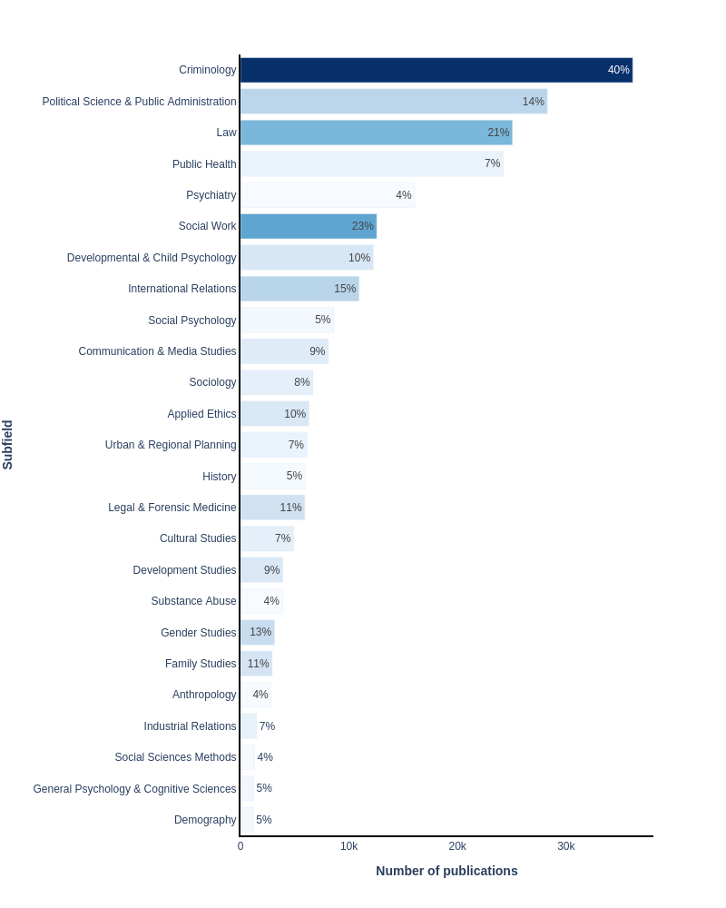

Figure 1. Top 25 subfields with the largest percentage of Scopus publication included in the publication set.

## Journals

In this section, we show how the publication set, captured by the query above, relates to scholarly journals. Journals are sorted in terms of their relevance using term frequency-inverse document frequency (TF-IDF). The horizontal bars are proportional to the number of publications contributed by the journal to the current publication set. The number alongside the horizontal bar is the proportion of the journal contributing to this publication set.

The articles on this topic are published most frequently in the following journals: *Journal of Interpersonal Violence* (4,752 publications), *Child Abuse and Neglect* (3,509), and *Lecture Notes in Computer Science (including subseries Lecture Notes in Artificial Intelligence and Lecture Notes in Bioinformatics)* (2,703).

Note, larger journals may not appear in the table below, as their SDG contribution may be relatively small compared to the size of the journal.

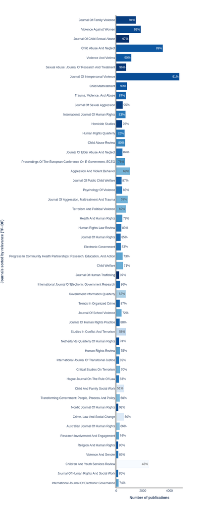

Figure 2. Top 50 journals, in terms of relevance (TF-IDF), for this publication set.

## Keywords

Elsevier’s [Scopus](https://www.scopus.com/search/form.uri?display=basic#basic) database of scientific literature, was used for the table below. The document types included in the data sets are journal articles, reviews, short surveys and conference papers, covering the period 1996–2022. We refer to these documents collectively as “publications” or “papers”.

In order to help better illustrate the content of this set of publications, indicators associated with the keywords most specific to this set (according to a TF-IDF score) are presented below.

|  | Term | # of papers with this term in the publication set | # of papers with this term in all of Scopus | Relevance (TF-IDF) | Percentage of Scopus |
| --- | --- | --- | --- | --- | --- |
| 1 | childhood maltreatment | 2633 | 2859 | 18.7507 | 92 |
| 2 | dating violence | 1982 | 2201 | 18.7156 | 90 |
| 3 | community-based participatory research (cbpr) | 1154 | 1235 | 18.712 | 93 |
| 4 | community-based participatory research | 4104 | 4414 | 18.6982 | 93 |
| 5 | violence perpetration | 949 | 999 | 18.687 | 95 |
| 6 | childhood abuse | 2983 | 3329 | 18.6849 | 90 |
| 7 | bullying victimization | 1246 | 1373 | 18.677 | 91 |
| 8 | violence victimization | 1038 | 1117 | 18.6752 | 93 |
| 9 | emotional abuse | 3347 | 3758 | 18.6555 | 89 |
| 10 | stakeholder involvement | 2808 | 3207 | 18.6473 | 88 |

[output cut: 990 more lines]